# **Facial Emotion Detection**

## **Problem Definition**

#### **The context:** Why is this problem important to solve?

In the field of human-machine interaction, facial expression recognition is critical. From recent research, it has been found that as much as 55% of communication of sentiment takes place through facial expressions and other visual cues. Therefore, training a model to identify facial emotions accurately is an important step towards the development of emotionally intelligent behavior in machines with AI capabilities. Automatic facial expression recognition systems could have many applications, including but not limited to any use case that requires human behavior understanding, detection of mental disorders, and creating a higher quality of virtual assistant for customer-facing businesses.

#### **The objectives:** What is the intended goal?

The goal of this project is to use Deep Learning and Artificial Intelligence techniques to create a computer vision model that can accurately detect facial emotions.

#### **The key questions:** What are the key questions that need to be answered?

- Is our data balanced? Are there enough samples and are the samples evenly distributed among our classes?
- What colorspace (rgb vs grayscale) will produce better results? My hypothesis is that feeding rgb images into our models will generate better results at the cost of higher computation times.
- How impactful will transfer learning be when compared to our base CNN models?

#### **The problem formulation:** What are we trying to solve using data science?

We are building a model that will be able to perform multi-class classification on images of facial expressions, to classify the expressions according to the associated emotion.

## **About the dataset**

The data set consists of 3 folders, i.e., 'test', 'train', and 'validation'. Each of these folders has four subfolders:

**‘happy’**: Images of people who have happy facial expressions.  
**‘sad’**: Images of people with sad or upset facial expressions.  
**‘surprise’**: Images of people who have shocked or surprised facial expressions.  
**‘neutral’**: Images of people showing no prominent emotion in their facial expression at all.

## **Mounting the Drive**

**NOTE:** Please use Google Colab from your browser for this notebook. **Google.colab is NOT a library that can be downloaded locally on your device.**

```python
#from google.colab import drive
#drive.mount('/content/drive')
```

## **Importing the Libraries**

```python
import h5py

import keras
import skimage
from skimage import io
from skimage.transform import resize
#import cv2

import pandas as pd
import numpy as np
import random

import zipfile
import os

# data visualization
import matplotlib.pyplot as plt
import seaborn as sns
sns.set()

import tensorflow as tf

# Keras Sequential Model
from tensorflow.keras.models import Sequential, Model

# Importing all the different layers and optimizers
from tensorflow.keras.layers import Dense, Dropout, Flatten, Conv2D, MaxPooling2D, BatchNormalization, Activation, LeakyReLU, Input
from tensorflow.keras import backend
from tensorflow.keras.utils import to_categorical
from tensorflow.keras.optimizers import Adam, SGD, RMSprop
from tensorflow.keras import losses, optimizers
from tensorflow.keras.preprocessing.image import load_img
from tensorflow.keras.preprocessing.image import ImageDataGenerator
from tensorflow.keras.callbacks import EarlyStopping, ModelCheckpoint, ReduceLROnPlateau

from sklearn.metrics import classification_report
from sklearn.metrics import confusion_matrix
#from google.colab.patches import cv2_imshow
```

```python
tf.version.VERSION
```

```
'2.17.0'
```

### **Let us load and unzip the data**

**Note:**

- You must download the dataset from the link provided on Olympus and upload the same on your Google drive before executing the code in the next cell.
- In case of any error, please make sure that the path of the file is correct as the path may be different for you.

```python
pathZip = 'Facial_emotion_images.zip'
```

```python
with zipfile.ZipFile(pathZip, 'r') as zip_ref:
  zip_ref.extractall()
```

```python
PATH = 'Facial_emotion_images'
DATADIR = 'Facial_emotion_images/train'
DATADIR_VAL = 'Facial_emotion_images/validation'
DATADIR_TEST = 'Facial_emotion_images/test'
CATEGORIES = ['happy', 'sad', 'neutral', 'surprise']
```

## **Visualizing our Classes**

Let's look at our classes.

**Write down your observation for each class. What do you think can be a unique feature of each emotion, that separates it from the remaining classes?**

### **Happy**

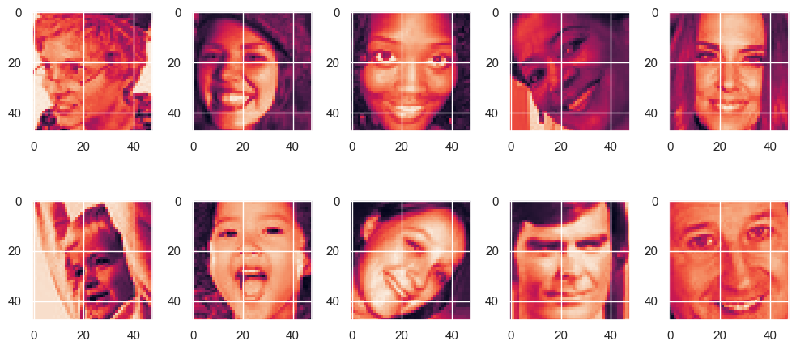

```python
#happy
happy_data = []

path = os.path.join(DATADIR, CATEGORIES[0])
for img in os.listdir(path):
  img_array = io.imread(os.path.join(path, img))
  happy_data.append(img_array)

rows = 2
cols = 5
x = 0

fig = plt.figure(figsize = (10,5))

for i in range(cols):
  for j in range(rows):
    ax = fig.add_subplot(rows, cols, i*rows+j+1)
    ax.imshow(happy_data[x])
    x = x + 1

plt.tight_layout()
plt.show()
```

**Observations and Insights:**

The unique features that stand out from the "Happy" images are:

- the smile (teeth showing in many of them / the shape of their mouth)
- raised eyebrows
- raised cheeks

### **Sad**

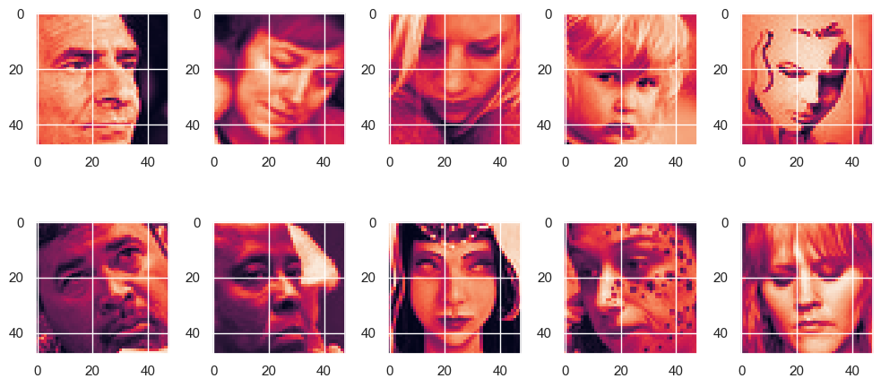

```python
#sad
sad_data = []

path = os.path.join(DATADIR, CATEGORIES[1])
for img in os.listdir(path):
  img_array = io.imread(os.path.join(path, img))
  sad_data.append(img_array)

rows = 2
cols = 5
x = 0

fig = plt.figure(figsize = (10,5))

for i in range(cols):
  for j in range(rows):
    ax = fig.add_subplot(rows, cols, i*rows+j+1)
    ax.imshow(sad_data[x])
    x = x + 1

plt.tight_layout()
plt.show()
```

**Observations and Insights:**

The unique features that standout in the "Sad" images are

- the eyes (squinting/looking downward)
- the downward shape of the mouth (inverted smile)
- the eyebrows (looks like a negative slope)
- the wrinkles on the forehead that come from "making a face" (though this feature is not present in all images)

### **Neutral**

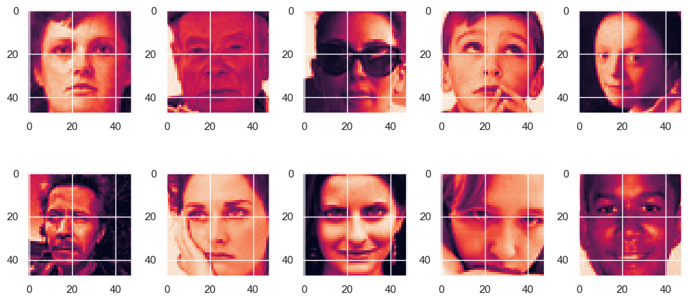

```python
#neutral
neutral_data = []

path = os.path.join(DATADIR, CATEGORIES[2])
for img in os.listdir(path):
  img_array = io.imread(os.path.join(path, img))
  neutral_data.append(img_array)

rows = 2
cols = 5
x = 0

fig = plt.figure(figsize = (10,5))

for i in range(cols):
  for j in range(rows):
    ax = fig.add_subplot(rows, cols, i*rows+j+1)
    ax.imshow(neutral_data[x])
    x = x + 1

plt.tight_layout()
plt.show()
```

**Observations and Insights:**

The prominent features of the "Neutral" images are:

- the rather straight or very slight downward shape of the mouth
- the lack of facial features that would stem from "making a face"
- this class seems to have some features from each of the other classes

### **Surprised**

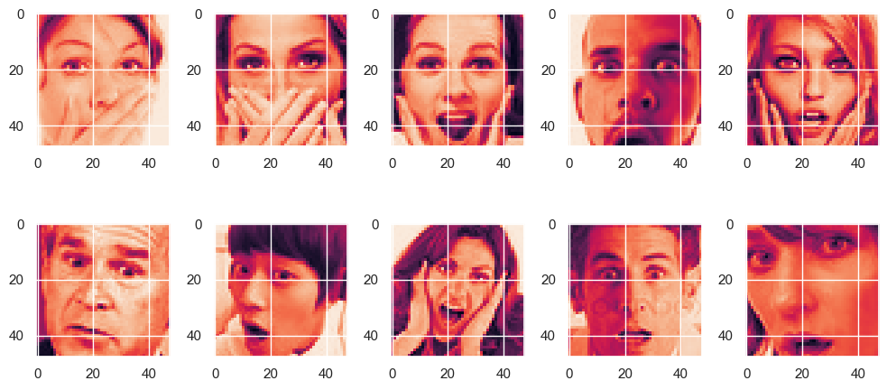

```python
#surprise
surprise_data = []

path = os.path.join(DATADIR, CATEGORIES[3])
for img in os.listdir(path):
  img_array = io.imread(os.path.join(path, img))
  surprise_data.append(img_array)

rows = 2
cols = 5
x = 0

fig = plt.figure(figsize = (10,5))

for i in range(cols):
  for j in range(rows):
    ax = fig.add_subplot(rows, cols, i*rows+j+1)
    ax.imshow(surprise_data[x])
    x = x + 1

plt.tight_layout()
plt.show()
```

**Observations and Insights:**

The most prominent feature of these "Suprised" images are:

- the wide/big eyes
- the opened mouths
- raised eyebrows
- it also seems like many of the pictures have hands on their face in them, which is also seen in the in other classes but less so based on the first 10 images of each class

# **Preprocessing Our Data**

```python
happy_data[0].shape, sad_data[0].shape, neutral_data[0].shape, surprise_data[0].shape
```

```
((48, 48), (48, 48), (48, 48), (48, 48))
```

```python
IMG_SIZE = 48
```

```python
#loading training data labels
training_labels = []

def create_training_labels():
  for category in CATEGORIES:
    path = os.path.join(DATADIR, category)
    class_num = category

    for img in os.listdir(path): #iterating through every file in directory
      training_labels.append(class_num) #appending image array and class label
```

```python
create_training_labels()
```

```python
len(training_labels)
```

```
15109
```

```python
training_labels[0] #looks like our function is working as intended, lets move on to retrieve the labels of validation and testing
```

```
'happy'
```

```python
#laoding test data labels
testing_labels = []

def create_testing_labels():
  for category in CATEGORIES:
    path = os.path.join(DATADIR_TEST, category)
    class_num = category

    for img in os.listdir(path): #iterating through every file in directory
      testing_labels.append(class_num) #appending image array and class label
```

```python
create_testing_labels()
```

```python
len(testing_labels)
```

```
128
```

```python
batch_size_testing = 128
```

```python
#loading val data labels
validation_labels = []

def create_validation_labels():
  for category in CATEGORIES:
    path = os.path.join(DATADIR_VAL, category)
    class_num = category

    for img in os.listdir(path): #iterating through every file in directory
      validation_labels.append(class_num) #appending image array and class label
```

```python
create_validation_labels()
```

```python
len(validation_labels)
```

```
4977
```

**Initial Observations:**

- Our four classes have images of size 48x48, so we set a global variable equal to 48 to use in our models parameters: img_size
- Our testing data has 128 images - we set our batch size for our testing data loader to be 128 to include all samples when evaluating on test set: batch_size_testing
- The training data and validation data have 15109 and 4977 images respectively

```python
training_labels = pd.DataFrame(training_labels, columns=['Label'], dtype=object)
validation_labels = pd.DataFrame(validation_labels, columns=['Label'], dtype=object)
testing_labels = pd.DataFrame(testing_labels, columns=['Label'], dtype=object)
```

```python
training_labels.head()
```

|  | Label |
| --- | --- |
| 0 | happy |
| 1 | happy |
| 2 | happy |
| 3 | happy |
| 4 | happy |

```python
training_labels.Label.value_counts(normalize = True)
```

```
Label
sad         0.263552
neutral     0.263287
happy       0.263154
surprise    0.210007
Name: proportion, dtype: float64
```

```python
training_labels.Label.value_counts()
```

```
Label
sad         3982
neutral     3978
happy       3976
surprise    3173
Name: count, dtype: int64
```

```python
validation_labels.Label.value_counts()
```

```
Label
happy       1825
neutral     1216
sad         1139
surprise     797
Name: count, dtype: int64
```

```python
validation_labels.Label.value_counts(normalize = True)
```

```
Label
happy       0.366687
neutral     0.244324
sad         0.228853
surprise    0.160137
Name: proportion, dtype: float64
```

```python
testing_labels.Label.value_counts()
```

```
Label
happy       32
sad         32
neutral     32
surprise    32
Name: count, dtype: int64
```

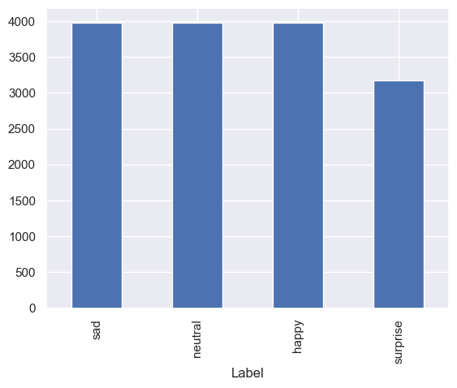

```python
training_labels.Label.value_counts().plot(kind = 'bar')
```

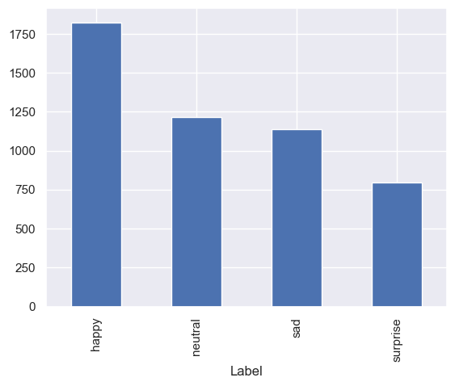

```python
validation_labels.Label.value_counts().plot(kind = 'bar')
```

**Observations and Insights:**

- Training data: The classes Happy, Neutral, and Sad have about the same distribution each having 26% (approx 4000 samples) of the data, whereas the class Surprise only has 21% (approx 3200 samples) of the data.
- Test data: The distribution of the classes are the same.
- Validation data: The distribution of the classes are as follows: happy (36%), neutral (24%), sad (23%), and surprise (16%).

I don't believe at this moment that the imbalance in our training data is too high, but the imbalance of classes in our validation data may cause performance issues in our models.

# **Model Building**

**CNNs vs ANNS** CNNs have two main advantages over ANNs when working on image data:

1. Local Spatiality
   - ANNs do a poor job at understanding local representation/patterns in the image data because ANNs needs images to be flattened into a 1D vector. This means that the vector of a flattened image and the vector of that same image but slightly rotated by x degrees produce vastly different vectors for our ANN.
2. Weight Sharing
   - In CNNs we use filters to detect features from an image, and the weights of any filter remain the same for all the patches in an image. Therefore information is extracted from the entire image instead of just a particular region.
   - Whereas ANNs don't have any weight sharing, each input node is multiplied by a weight of its own.

For the reasons above, we will be using CNNs to build our models.

## Grayscale

### **Creating our Data Loaders**

```python
batch_size  = 32

datagen_train = ImageDataGenerator(horizontal_flip = True,
                                    brightness_range=(0.,2.),
                                    rescale=1./255,
                                    shear_range=0.2,)

train_set = datagen_train.flow_from_directory(DATADIR,
                                              target_size = (IMG_SIZE, IMG_SIZE),
                                              color_mode = 'grayscale' ,
                                              batch_size = batch_size,
                                              class_mode = 'categorical',
                                              classes = ['happy', 'neutral', 'sad', 'surprise'],
                                              shuffle = True)


datagen_val = ImageDataGenerator(horizontal_flip = True,
                                    brightness_range=(0.,2.),
                                    rescale=1./255,
                                    shear_range=0.2,)

val_set = datagen_val.flow_from_directory(DATADIR_VAL,
                                              target_size = (IMG_SIZE, IMG_SIZE),
                                              color_mode = 'grayscale' ,
                                              batch_size = batch_size,
                                              class_mode = 'categorical',
                                              classes = ['happy', 'neutral', 'sad', 'surprise'],
                                              shuffle = True)


datagen_test = ImageDataGenerator(horizontal_flip = True,
                                    brightness_range=(0.,2.),
                                    rescale=1./255,
                                    shear_range=0.2,)

test_set = datagen_test.flow_from_directory(DATADIR_TEST,
                                              target_size = (IMG_SIZE, IMG_SIZE),
                                              color_mode = 'grayscale' ,
                                              batch_size = batch_size_testing,
                                              class_mode = 'categorical',
                                              classes = ['happy', 'neutral', 'sad', 'surprise'],
                                              shuffle = True)
```

```
Found 15109 images belonging to 4 classes.
Found 4977 images belonging to 4 classes.
Found 128 images belonging to 4 classes.
```

### **Base CNN (grayscale)**

#### **Defining and Compiling the Model**

```python
from tensorflow.keras import backend
backend.clear_session()
```

```
WARNING:tensorflow:From D:\Data_Tools\Anaconda2\Lib\site-packages\keras\src\backend\common\global_state.py:82: The name tf.reset_default_graph is deprecated. Please use tf.compat.v1.reset_default_graph instead.
```

```python
np.random.seed(25)
random.seed(25)
tf.random.set_seed(25)
```

```python
def cnn_model_base():

    model = Sequential()
    model.add(Input(shape = (IMG_SIZE, IMG_SIZE, 1))) #, input_shape = (IMG_SIZE, IMG_SIZE, 1)))

    model.add(Conv2D(filters = 64, kernel_size = (3,3), activation = 'relu', padding='same'))
    model.add(MaxPooling2D(pool_size=(2,2)))

    model.add(Conv2D(filters = 32, kernel_size = (3,3), activation = 'relu', padding='same'))
    model.add(MaxPooling2D(pool_size=(2,2)))

    model.add(Conv2D(filters = 32, kernel_size = (3,3), activation = 'relu', padding='same'))
    model.add(MaxPooling2D(pool_size=(2,2)))

    model.add(Flatten())

    model.add(Dense(256))
    model.add(LeakyReLU(0.1))

    model.add(Dense(4, activation = 'softmax'))

    opt = SGD(learning_rate = 0.01, momentum = 0.9)

    model.compile(loss = "categorical_crossentropy", optimizer = opt, metrics = ["accuracy"])

    return model
```

```python
cnn_base = cnn_model_base()
cnn_base.summary()
```

```
Model: "sequential"
```

```
┏━━━━━━━━━━━━━━━━━━━━━━━━━━━━━━━━━┳━━━━━━━━━━━━━━━━━━━━━━━━┳━━━━━━━━━━━━━━━┓
┃ Layer (type)                    ┃ Output Shape           ┃       Param # ┃
┡━━━━━━━━━━━━━━━━━━━━━━━━━━━━━━━━━╇━━━━━━━━━━━━━━━━━━━━━━━━╇━━━━━━━━━━━━━━━┩
│ conv2d (Conv2D)                 │ (None, 48, 48, 64)     │           640 │
├─────────────────────────────────┼────────────────────────┼───────────────┤
│ max_pooling2d (MaxPooling2D)    │ (None, 24, 24, 64)     │             0 │
├─────────────────────────────────┼────────────────────────┼───────────────┤
│ conv2d_1 (Conv2D)               │ (None, 24, 24, 32)     │        18,464 │
├─────────────────────────────────┼────────────────────────┼───────────────┤
│ max_pooling2d_1 (MaxPooling2D)  │ (None, 12, 12, 32)     │             0 │
├─────────────────────────────────┼────────────────────────┼───────────────┤
│ conv2d_2 (Conv2D)               │ (None, 12, 12, 32)     │         9,248 │
├─────────────────────────────────┼────────────────────────┼───────────────┤
│ max_pooling2d_2 (MaxPooling2D)  │ (None, 6, 6, 32)       │             0 │
├─────────────────────────────────┼────────────────────────┼───────────────┤
│ flatten (Flatten)               │ (None, 1152)           │             0 │
├─────────────────────────────────┼────────────────────────┼───────────────┤
│ dense (Dense)                   │ (None, 256)            │       295,168 │
├─────────────────────────────────┼────────────────────────┼───────────────┤
│ leaky_re_lu (LeakyReLU)         │ (None, 256)            │             0 │
├─────────────────────────────────┼────────────────────────┼───────────────┤
│ dense_1 (Dense)                 │ (None, 4)              │         1,028 │
└─────────────────────────────────┴────────────────────────┴───────────────┘
```

```
 Total params: 324,548 (1.24 MB)
```

```
 Trainable params: 324,548 (1.24 MB)
```

```
 Non-trainable params: 0 (0.00 B)
```

```python
early_stop = EarlyStopping(monitor='val_loss', mode = 'min', patience = 5, verbose = 1, restore_best_weights = True)
checkpoint = ModelCheckpoint('best_model_base.keras', monitor='val_loss', mode = 'min', verbose = 1, save_best_only = True)
reduce_lr = ReduceLROnPlateau(monitor = 'val_loss', factor = 0.2, patience = 3, verbose = 1, min_delta = 0.0001)

history_cnn_base = cnn_base.fit(train_set, validation_data = val_set, epochs = 200, verbose = 1, callbacks = [early_stop, checkpoint, reduce_lr])
```

```
  5/473 ━━━━━━━━━━━━━━━━━━━━ 7s 15ms/step - accuracy: 0.1658 - loss: 1.3948
```

```
470/473 ━━━━━━━━━━━━━━━━━━━━ 0s 17ms/step - accuracy: 0.2771 - loss: 1.3775
Epoch 1: val_loss improved from inf to 1.29510, saving model to best_model_base.keras
473/473 ━━━━━━━━━━━━━━━━━━━━ 24s 49ms/step - accuracy: 0.2773 - loss: 1.3773 - val_accuracy: 0.3187 - val_loss: 1.2951 - learning_rate: 0.0100
466/473 ━━━━━━━━━━━━━━━━━━━━ 0s 17ms/step - accuracy: 0.4242 - loss: 1.2385
Epoch 2: val_loss improved from 1.29510 to 1.16530, saving model to best_model_base.keras
473/473 ━━━━━━━━━━━━━━━━━━━━ 10s 22ms/step - accuracy: 0.4246 - loss: 1.2380 - val_accuracy: 0.4830 - val_loss: 1.1653 - learning_rate: 0.0100
473/473 ━━━━━━━━━━━━━━━━━━━━ 0s 17ms/step - accuracy: 0.4993 - loss: 1.1360
Epoch 3: val_loss improved from 1.16530 to 1.08366, saving model to best_model_base.keras
473/473 ━━━━━━━━━━━━━━━━━━━━ 10s 21ms/step - accuracy: 0.4993 - loss: 1.1360 - val_accuracy: 0.5234 - val_loss: 1.0837 - learning_rate: 0.0100
466/473 ━━━━━━━━━━━━━━━━━━━━ 0s 17ms/step - accuracy: 0.5387 - loss: 1.0689
Epoch 4: val_loss improved from 1.08366 to 1.02640, saving model to best_model_base.keras
473/473 ━━━━━━━━━━━━━━━━━━━━ 10s 22ms/step - accuracy: 0.5387 - loss: 1.0688 - val_accuracy: 0.5666 - val_loss: 1.0264 - learning_rate: 0.0100
466/473 ━━━━━━━━━━━━━━━━━━━━ 0s 17ms/step - accuracy: 0.5543 - loss: 1.0237
Epoch 5: val_loss improved from 1.02640 to 0.98934, saving model to best_model_base.keras
473/473 ━━━━━━━━━━━━━━━━━━━━ 10s 21ms/step - accuracy: 0.5544 - loss: 1.0236 - val_accuracy: 0.5825 - val_loss: 0.9893 - learning_rate: 0.0100
467/473 ━━━━━━━━━━━━━━━━━━━━ 0s 17ms/step - accuracy: 0.5846 - loss: 0.9729
Epoch 6: val_loss improved from 0.98934 to 0.94276, saving model to best_model_base.keras
473/473 ━━━━━━━━━━━━━━━━━━━━ 10s 21ms/step - accuracy: 0.5845 - loss: 0.9730 - val_accuracy: 0.6018 - val_loss: 0.9428 - learning_rate: 0.0100
470/473 ━━━━━━━━━━━━━━━━━━━━ 0s 17ms/step - accuracy: 0.5893 - loss: 0.9544
Epoch 7: val_loss improved from 0.94276 to 0.93755, saving model to best_model_base.keras
473/473 ━━━━━━━━━━━━━━━━━━━━ 10s 21ms/step - accuracy: 0.5894 - loss: 0.9543 - val_accuracy: 0.6098 - val_loss: 0.9375 - learning_rate: 0.0100
471/473 ━━━━━━━━━━━━━━━━━━━━ 0s 16ms/step - accuracy: 0.6103 - loss: 0.9144
Epoch 8: val_loss improved from 0.93755 to 0.88484, saving model to best_model_base.keras
473/473 ━━━━━━━━━━━━━━━━━━━━ 10s 20ms/step - accuracy: 0.6103 - loss: 0.9144 - val_accuracy: 0.6333 - val_loss: 0.8848 - learning_rate: 0.0100
466/473 ━━━━━━━━━━━━━━━━━━━━ 0s 16ms/step - accuracy: 0.6288 - loss: 0.8745
Epoch 9: val_loss did not improve from 0.88484
473/473 ━━━━━━━━━━━━━━━━━━━━ 9s 20ms/step - accuracy: 0.6288 - loss: 0.8745 - val_accuracy: 0.6166 - val_loss: 0.9331 - learning_rate: 0.0100
466/473 ━━━━━━━━━━━━━━━━━━━━ 0s 15ms/step - accuracy: 0.6348 - loss: 0.8548
Epoch 10: val_loss improved from 0.88484 to 0.85803, saving model to best_model_base.keras
473/473 ━━━━━━━━━━━━━━━━━━━━ 9s 20ms/step - accuracy: 0.6348 - loss: 0.8548 - val_accuracy: 0.6472 - val_loss: 0.8580 - learning_rate: 0.0100
467/473 ━━━━━━━━━━━━━━━━━━━━ 0s 15ms/step - accuracy: 0.6586 - loss: 0.8154
Epoch 11: val_loss did not improve from 0.85803
473/473 ━━━━━━━━━━━━━━━━━━━━ 9s 19ms/step - accuracy: 0.6586 - loss: 0.8156 - val_accuracy: 0.5620 - val_loss: 1.0029 - learning_rate: 0.0100
466/473 ━━━━━━━━━━━━━━━━━━━━ 0s 15ms/step - accuracy: 0.6608 - loss: 0.8158
Epoch 12: val_loss did not improve from 0.85803
473/473 ━━━━━━━━━━━━━━━━━━━━ 9s 19ms/step - accuracy: 0.6608 - loss: 0.8157 - val_accuracy: 0.6438 - val_loss: 0.8589 - learning_rate: 0.0100
470/473 ━━━━━━━━━━━━━━━━━━━━ 0s 15ms/step - accuracy: 0.6650 - loss: 0.7978
Epoch 13: val_loss did not improve from 0.85803

Epoch 13: ReduceLROnPlateau reducing learning rate to 0.0019999999552965165.
```

[output cut: 40 more lines]

```
Epoch 26: val_loss did not improve from 0.79956
473/473 ━━━━━━━━━━━━━━━━━━━━ 10s 20ms/step - accuracy: 0.7711 - loss: 0.5825 - val_accuracy: 0.6858 - val_loss: 0.8275 - learning_rate: 4.0000e-04
470/473 ━━━━━━━━━━━━━━━━━━━━ 0s 16ms/step - accuracy: 0.7697 - loss: 0.5715
Epoch 27: val_loss did not improve from 0.79956

Epoch 27: ReduceLROnPlateau reducing learning rate to 7.999999215826393e-05.
473/473 ━━━━━━━━━━━━━━━━━━━━ 10s 20ms/step - accuracy: 0.7697 - loss: 0.5715 - val_accuracy: 0.6856 - val_loss: 0.8152 - learning_rate: 4.0000e-04
465/473 ━━━━━━━━━━━━━━━━━━━━ 0s 16ms/step - accuracy: 0.7786 - loss: 0.5628
Epoch 28: val_loss did not improve from 0.79956
473/473 ━━━━━━━━━━━━━━━━━━━━ 10s 20ms/step - accuracy: 0.7786 - loss: 0.5628 - val_accuracy: 0.6781 - val_loss: 0.8230 - learning_rate: 8.0000e-05
467/473 ━━━━━━━━━━━━━━━━━━━━ 0s 16ms/step - accuracy: 0.7754 - loss: 0.5667
Epoch 29: val_loss did not improve from 0.79956
473/473 ━━━━━━━━━━━━━━━━━━━━ 10s 20ms/step - accuracy: 0.7754 - loss: 0.5667 - val_accuracy: 0.6813 - val_loss: 0.8137 - learning_rate: 8.0000e-05
Epoch 29: early stopping
Restoring model weights from the end of the best epoch: 24.
```

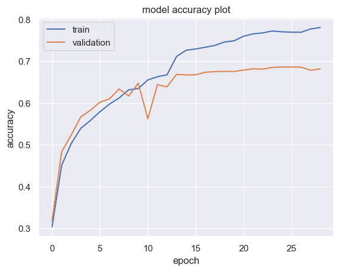

```python
plt.plot(history_cnn_base.history['accuracy'])
plt.plot(history_cnn_base.history['val_accuracy'])

plt.title('model accuracy plot')
plt.ylabel('accuracy')
plt.xlabel('epoch')
plt.legend(['train', 'validation'])

plt.show()
```

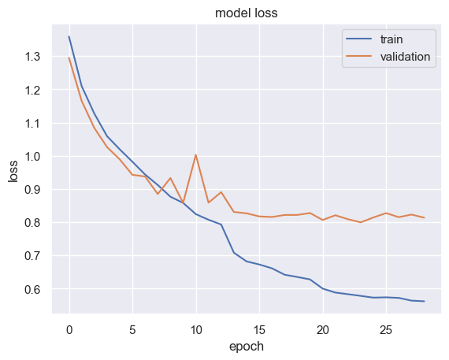

```python
plt.plot(history_cnn_base.history['loss'])
plt.plot(history_cnn_base.history['val_loss'])

plt.title('model loss')
plt.ylabel('loss')
plt.xlabel('epoch')
plt.legend(['train', 'validation'])

plt.show()
```

#### **Model Evaluation**

```python
test_images, test_labels = next(test_set)
```

```python
accuracy = cnn_base.evaluate(test_images, test_labels, verbose = 2)
```

```
4/4 - 0s - 5ms/step - accuracy: 0.6797 - loss: 0.8310
```

```python
#lists for model name and accuracy
scoreboard_name = []
scoreboard_acc = []
scoreboard = []

#saving model name and accuracy
scoreboard_name.append('cnn_base')
scoreboard_acc.append(accuracy)

scoreboard.append(['cnn_base', accuracy[1]])
```

##### **Observations and Insights:**

- The model clearly overfits our training data: our validation data accuracy (68%) and loss (0.8) start to plateau at the around the 14th epoch while our training data continues to improve, slowing down at around the 23rd epoch.
- It is therefore not giving a generalized performance.
- Our learning rate of 0.01 seems to have worked pretty well on our training data, achieving 77% accuracy at the 24th epoch.
- The accuracy on the test set is just under 68% which is similar to the accuracy of our validation data.

### **Second Base CNN (grayscale)**

Let's try a smaller SGD learning rate in our base cnn model (lr = 0.001) to compare.

#### **Defining and Compiling the Model**

```python
backend.clear_session()

np.random.seed(25)
random.seed(25)
tf.random.set_seed(25)
```

```python
def cnn_model_base1():

    model = Sequential()
    model.add(Input(shape = (IMG_SIZE, IMG_SIZE, 1))) #, input_shape = (IMG_SIZE, IMG_SIZE, 1)))

    model.add(Conv2D(filters = 64, kernel_size = (3,3), activation = 'relu', padding='same'))
    model.add(MaxPooling2D(pool_size=(2,2)))

    model.add(Conv2D(filters = 32, kernel_size = (3,3), activation = 'relu', padding='same'))
    model.add(MaxPooling2D(pool_size=(2,2)))

    model.add(Conv2D(filters = 32, kernel_size = (3,3), activation = 'relu', padding='same'))
    model.add(MaxPooling2D(pool_size=(2,2)))

    model.add(Flatten())

    model.add(Dense(256))
    model.add(LeakyReLU(0.1))

    model.add(Dense(4, activation = 'softmax'))

    opt = SGD(learning_rate = 0.001, momentum = 0.9)

    model.compile(loss = "categorical_crossentropy", optimizer = opt, metrics = ["accuracy"])

    return model
```

```python
cnn_base1 = cnn_model_base1()
cnn_base1.summary()
```

```
Model: "sequential"
```

```
┏━━━━━━━━━━━━━━━━━━━━━━━━━━━━━━━━━┳━━━━━━━━━━━━━━━━━━━━━━━━┳━━━━━━━━━━━━━━━┓
┃ Layer (type)                    ┃ Output Shape           ┃       Param # ┃
┡━━━━━━━━━━━━━━━━━━━━━━━━━━━━━━━━━╇━━━━━━━━━━━━━━━━━━━━━━━━╇━━━━━━━━━━━━━━━┩
│ conv2d (Conv2D)                 │ (None, 48, 48, 64)     │           640 │
├─────────────────────────────────┼────────────────────────┼───────────────┤
│ max_pooling2d (MaxPooling2D)    │ (None, 24, 24, 64)     │             0 │
├─────────────────────────────────┼────────────────────────┼───────────────┤
│ conv2d_1 (Conv2D)               │ (None, 24, 24, 32)     │        18,464 │
├─────────────────────────────────┼────────────────────────┼───────────────┤
│ max_pooling2d_1 (MaxPooling2D)  │ (None, 12, 12, 32)     │             0 │
├─────────────────────────────────┼────────────────────────┼───────────────┤
│ conv2d_2 (Conv2D)               │ (None, 12, 12, 32)     │         9,248 │
├─────────────────────────────────┼────────────────────────┼───────────────┤
│ max_pooling2d_2 (MaxPooling2D)  │ (None, 6, 6, 32)       │             0 │
├─────────────────────────────────┼────────────────────────┼───────────────┤
│ flatten (Flatten)               │ (None, 1152)           │             0 │
├─────────────────────────────────┼────────────────────────┼───────────────┤
│ dense (Dense)                   │ (None, 256)            │       295,168 │
├─────────────────────────────────┼────────────────────────┼───────────────┤
│ leaky_re_lu (LeakyReLU)         │ (None, 256)            │             0 │
├─────────────────────────────────┼────────────────────────┼───────────────┤
│ dense_1 (Dense)                 │ (None, 4)              │         1,028 │
└─────────────────────────────────┴────────────────────────┴───────────────┘
```

```
 Total params: 324,548 (1.24 MB)
```

```
 Trainable params: 324,548 (1.24 MB)
```

```
 Non-trainable params: 0 (0.00 B)
```

```python
early_stop = EarlyStopping(monitor='val_loss', mode = 'min', patience = 5, verbose = 1, restore_best_weights = True)
checkpoint = ModelCheckpoint('best_model_base1.keras', monitor='val_loss', mode = 'min', verbose = 1, save_best_only = True)
reduce_lr = ReduceLROnPlateau(monitor = 'val_loss', factor = 0.2, patience = 3, verbose = 1, min_delta = 0.0001)

history_cnn_base1 = cnn_base1.fit(train_set, validation_data = val_set, epochs = 200, verbose = 1, callbacks = [early_stop, checkpoint, reduce_lr])
```

```
465/473 ━━━━━━━━━━━━━━━━━━━━ 0s 16ms/step - accuracy: 0.2675 - loss: 1.3839
Epoch 1: val_loss improved from inf to 1.36982, saving model to best_model_base1.keras
473/473 ━━━━━━━━━━━━━━━━━━━━ 10s 20ms/step - accuracy: 0.2677 - loss: 1.3838 - val_accuracy: 0.3277 - val_loss: 1.3698 - learning_rate: 0.0010
466/473 ━━━━━━━━━━━━━━━━━━━━ 0s 16ms/step - accuracy: 0.2995 - loss: 1.3753
Epoch 2: val_loss improved from 1.36982 to 1.36074, saving model to best_model_base1.keras
473/473 ━━━━━━━━━━━━━━━━━━━━ 10s 20ms/step - accuracy: 0.2994 - loss: 1.3752 - val_accuracy: 0.3384 - val_loss: 1.3607 - learning_rate: 0.0010
467/473 ━━━━━━━━━━━━━━━━━━━━ 0s 16ms/step - accuracy: 0.3087 - loss: 1.3696
Epoch 3: val_loss did not improve from 1.36074
473/473 ━━━━━━━━━━━━━━━━━━━━ 10s 20ms/step - accuracy: 0.3087 - loss: 1.3696 - val_accuracy: 0.2829 - val_loss: 1.3711 - learning_rate: 0.0010
465/473 ━━━━━━━━━━━━━━━━━━━━ 0s 16ms/step - accuracy: 0.3122 - loss: 1.3636
Epoch 4: val_loss improved from 1.36074 to 1.33178, saving model to best_model_base1.keras
473/473 ━━━━━━━━━━━━━━━━━━━━ 10s 20ms/step - accuracy: 0.3124 - loss: 1.3635 - val_accuracy: 0.3490 - val_loss: 1.3318 - learning_rate: 0.0010
467/473 ━━━━━━━━━━━━━━━━━━━━ 0s 16ms/step - accuracy: 0.3404 - loss: 1.3450
Epoch 5: val_loss improved from 1.33178 to 1.28908, saving model to best_model_base1.keras
473/473 ━━━━━━━━━━━━━━━━━━━━ 10s 20ms/step - accuracy: 0.3405 - loss: 1.3449 - val_accuracy: 0.4229 - val_loss: 1.2891 - learning_rate: 0.0010
465/473 ━━━━━━━━━━━━━━━━━━━━ 0s 16ms/step - accuracy: 0.3762 - loss: 1.3140
Epoch 6: val_loss improved from 1.28908 to 1.28447, saving model to best_model_base1.keras
473/473 ━━━━━━━━━━━━━━━━━━━━ 10s 20ms/step - accuracy: 0.3765 - loss: 1.3137 - val_accuracy: 0.3711 - val_loss: 1.2845 - learning_rate: 0.0010
465/473 ━━━━━━━━━━━━━━━━━━━━ 0s 16ms/step - accuracy: 0.4165 - loss: 1.2596
Epoch 7: val_loss improved from 1.28447 to 1.19421, saving model to best_model_base1.keras
473/473 ━━━━━━━━━━━━━━━━━━━━ 10s 20ms/step - accuracy: 0.4168 - loss: 1.2594 - val_accuracy: 0.4874 - val_loss: 1.1942 - learning_rate: 0.0010
466/473 ━━━━━━━━━━━━━━━━━━━━ 0s 16ms/step - accuracy: 0.4519 - loss: 1.2259
Epoch 8: val_loss improved from 1.19421 to 1.17924, saving model to best_model_base1.keras
473/473 ━━━━━━━━━━━━━━━━━━━━ 10s 20ms/step - accuracy: 0.4521 - loss: 1.2257 - val_accuracy: 0.5043 - val_loss: 1.1792 - learning_rate: 0.0010
472/473 ━━━━━━━━━━━━━━━━━━━━ 0s 16ms/step - accuracy: 0.4749 - loss: 1.1980
Epoch 9: val_loss did not improve from 1.17924
473/473 ━━━━━━━━━━━━━━━━━━━━ 10s 20ms/step - accuracy: 0.4749 - loss: 1.1980 - val_accuracy: 0.4985 - val_loss: 1.1812 - learning_rate: 0.0010
466/473 ━━━━━━━━━━━━━━━━━━━━ 0s 16ms/step - accuracy: 0.4971 - loss: 1.1775
Epoch 10: val_loss improved from 1.17924 to 1.17053, saving model to best_model_base1.keras
473/473 ━━━━━━━━━━━━━━━━━━━━ 10s 21ms/step - accuracy: 0.4970 - loss: 1.1775 - val_accuracy: 0.5041 - val_loss: 1.1705 - learning_rate: 0.0010
466/473 ━━━━━━━━━━━━━━━━━━━━ 0s 16ms/step - accuracy: 0.4947 - loss: 1.1673
Epoch 11: val_loss improved from 1.17053 to 1.14049, saving model to best_model_base1.keras
473/473 ━━━━━━━━━━━━━━━━━━━━ 10s 20ms/step - accuracy: 0.4947 - loss: 1.1672 - val_accuracy: 0.5272 - val_loss: 1.1405 - learning_rate: 0.0010
468/473 ━━━━━━━━━━━━━━━━━━━━ 0s 16ms/step - accuracy: 0.5019 - loss: 1.1498
Epoch 12: val_loss improved from 1.14049 to 1.13380, saving model to best_model_base1.keras
473/473 ━━━━━━━━━━━━━━━━━━━━ 10s 20ms/step - accuracy: 0.5020 - loss: 1.1498 - val_accuracy: 0.5264 - val_loss: 1.1338 - learning_rate: 0.0010
469/473 ━━━━━━━━━━━━━━━━━━━━ 0s 17ms/step - accuracy: 0.5118 - loss: 1.1422
Epoch 13: val_loss improved from 1.13380 to 1.11724, saving model to best_model_base1.keras
473/473 ━━━━━━━━━━━━━━━━━━━━ 10s 22ms/step - accuracy: 0.5118 - loss: 1.1421 - val_accuracy: 0.5335 - val_loss: 1.1172 - learning_rate: 0.0010
470/473 ━━━━━━━━━━━━━━━━━━━━ 0s 21ms/step - accuracy: 0.5142 - loss: 1.1334
```

[output cut: 89 more lines]

```
Epoch 43: val_loss did not improve from 0.90529
473/473 ━━━━━━━━━━━━━━━━━━━━ 10s 20ms/step - accuracy: 0.6579 - loss: 0.8348 - val_accuracy: 0.6227 - val_loss: 0.9224 - learning_rate: 2.0000e-04
471/473 ━━━━━━━━━━━━━━━━━━━━ 0s 16ms/step - accuracy: 0.6562 - loss: 0.8391
Epoch 44: val_loss did not improve from 0.90529

Epoch 44: ReduceLROnPlateau reducing learning rate to 4.0000001899898055e-05.
473/473 ━━━━━━━━━━━━━━━━━━━━ 10s 20ms/step - accuracy: 0.6562 - loss: 0.8390 - val_accuracy: 0.6301 - val_loss: 0.9194 - learning_rate: 2.0000e-04
466/473 ━━━━━━━━━━━━━━━━━━━━ 0s 16ms/step - accuracy: 0.6616 - loss: 0.8248
Epoch 45: val_loss did not improve from 0.90529
473/473 ━━━━━━━━━━━━━━━━━━━━ 10s 20ms/step - accuracy: 0.6616 - loss: 0.8249 - val_accuracy: 0.6349 - val_loss: 0.9162 - learning_rate: 4.0000e-05
470/473 ━━━━━━━━━━━━━━━━━━━━ 0s 16ms/step - accuracy: 0.6632 - loss: 0.8311
Epoch 46: val_loss did not improve from 0.90529
473/473 ━━━━━━━━━━━━━━━━━━━━ 10s 20ms/step - accuracy: 0.6632 - loss: 0.8311 - val_accuracy: 0.6337 - val_loss: 0.9155 - learning_rate: 4.0000e-05
Epoch 46: early stopping
Restoring model weights from the end of the best epoch: 41.
```

#### **Model Evaluation**

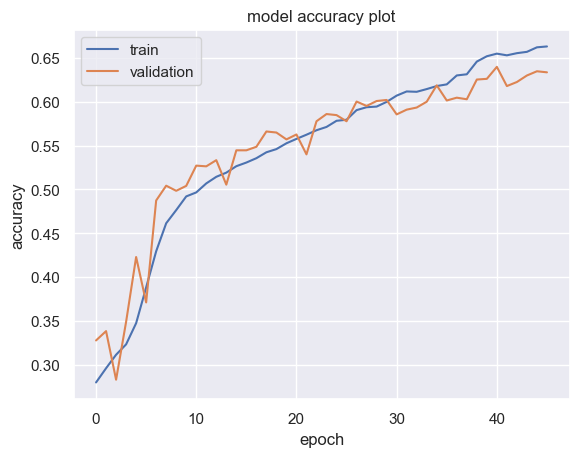

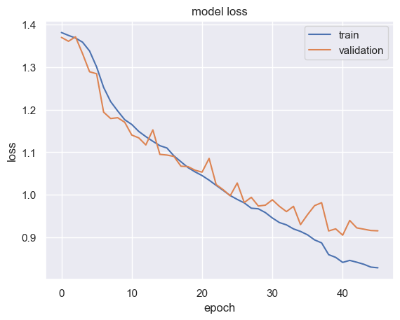

```python
plt.plot(history_cnn_base1.history['accuracy'])
plt.plot(history_cnn_base1.history['val_accuracy'])

plt.title('model accuracy plot')
plt.ylabel('accuracy')
plt.xlabel('epoch')
plt.legend(['train', 'validation'])

plt.show()

plt.plot(history_cnn_base1.history['loss'])
plt.plot(history_cnn_base1.history['val_loss'])

plt.title('model loss')
plt.ylabel('loss')
plt.xlabel('epoch')
plt.legend(['train', 'validation'])

plt.show()
```

```python
accuracy = cnn_base1.evaluate(test_images, test_labels, verbose = 2)
```

```
4/4 - 0s - 5ms/step - accuracy: 0.6016 - loss: 0.9580
```

```python
#saving model name and accuracy
scoreboard_name.append('cnn_base1')
scoreboard_acc.append(accuracy)

scoreboard.append(['cnn_base1', accuracy[1]])
```

##### **Observations and Insights: TODO**

- The model is still overfitting the training data. This makes sense as we did not add any dropout layers to reduce overfitting and that this model is identical to the previous with the only change being the learning rate.
- The higher learning rate performed better on the test set and was much quicker to achieve better results than the lower learning rate. However, we can say that the lower learning rate gave us a slightly better generalized performance (training and validation sets accuracy are slightly closer to one another).
- We should try different learning rates between the two. We'll do more hyperparameter tuning at the end. For the sake of simplicity, lets go with a learning rate of 0.01 for the SGD optimizer for the rest of our models and compare. We will tune this hyperparameter later on when we try to find our best model for this problem.
- The accuracy on the training set is much lower than our previous base model, sitting at 66% versus 77%. Which indicates that the learning rate might be too low and our model is not learning quick enough (this model ran for almost double the epochs of our previous one and performed worse on all three sets of data).

### **Third CNN (grayscale)**

Let's try a slightly larger architecture

#### **Defining and Compiling the Model**

```python
backend.clear_session()

np.random.seed(25)
random.seed(25)
tf.random.set_seed(25)
```

```python
def cnn_model_1():

    model = Sequential()
    model.add(Input(shape = (IMG_SIZE, IMG_SIZE, 1))) #input layer

    model.add(Conv2D(filters = 256, kernel_size = (3,3), activation = 'relu', padding='same')) # conv1
    model.add(BatchNormalization())
    model.add(LeakyReLU(0.1))
    model.add(MaxPooling2D(pool_size=(2,2)))

    model.add(Conv2D(filters = 128, kernel_size = (3,3), activation = 'relu', padding='same')) #conv 2
    model.add(BatchNormalization())
    model.add(LeakyReLU(0.1))
    model.add(MaxPooling2D(pool_size=(2,2)))


    model.add(Conv2D(filters = 64, kernel_size = (3,3), activation = 'relu', padding='same')) #conv 3
    model.add(BatchNormalization())
    model.add(LeakyReLU(0.1))
    model.add(MaxPooling2D(pool_size=(2,2)))

    model.add(Conv2D(filters = 32, kernel_size = (3,3), activation = 'relu', padding='same')) #conv 4
    model.add(BatchNormalization())
    model.add(LeakyReLU(0.1))
    model.add(MaxPooling2D(pool_size=(2,2)))

    model.add(Flatten())

    model.add(Dense(512, activation = 'relu'))
    model.add(Dense(128, activation = 'relu'))

    model.add(Dense(4, activation = 'softmax')) #output layer

    opt = SGD(learning_rate = 0.01, momentum = 0.9)

    model.compile(loss = "categorical_crossentropy", optimizer = opt, metrics = ["accuracy"])

    return model
```

```python
cnn_1 = cnn_model_1()
cnn_1.summary()
```

```
Model: "sequential"
```

```
┏━━━━━━━━━━━━━━━━━━━━━━━━━━━━━━━━━┳━━━━━━━━━━━━━━━━━━━━━━━━┳━━━━━━━━━━━━━━━┓
┃ Layer (type)                    ┃ Output Shape           ┃       Param # ┃
┡━━━━━━━━━━━━━━━━━━━━━━━━━━━━━━━━━╇━━━━━━━━━━━━━━━━━━━━━━━━╇━━━━━━━━━━━━━━━┩
│ conv2d (Conv2D)                 │ (None, 48, 48, 256)    │         2,560 │
├─────────────────────────────────┼────────────────────────┼───────────────┤
│ batch_normalization             │ (None, 48, 48, 256)    │         1,024 │
│ (BatchNormalization)            │                        │               │
├─────────────────────────────────┼────────────────────────┼───────────────┤
│ leaky_re_lu (LeakyReLU)         │ (None, 48, 48, 256)    │             0 │
├─────────────────────────────────┼────────────────────────┼───────────────┤
│ max_pooling2d (MaxPooling2D)    │ (None, 24, 24, 256)    │             0 │
├─────────────────────────────────┼────────────────────────┼───────────────┤
│ conv2d_1 (Conv2D)               │ (None, 24, 24, 128)    │       295,040 │
├─────────────────────────────────┼────────────────────────┼───────────────┤
│ batch_normalization_1           │ (None, 24, 24, 128)    │           512 │
│ (BatchNormalization)            │                        │               │
├─────────────────────────────────┼────────────────────────┼───────────────┤
│ leaky_re_lu_1 (LeakyReLU)       │ (None, 24, 24, 128)    │             0 │
├─────────────────────────────────┼────────────────────────┼───────────────┤
│ max_pooling2d_1 (MaxPooling2D)  │ (None, 12, 12, 128)    │             0 │
├─────────────────────────────────┼────────────────────────┼───────────────┤
│ conv2d_2 (Conv2D)               │ (None, 12, 12, 64)     │        73,792 │
├─────────────────────────────────┼────────────────────────┼───────────────┤
│ batch_normalization_2           │ (None, 12, 12, 64)     │           256 │
│ (BatchNormalization)            │                        │               │
├─────────────────────────────────┼────────────────────────┼───────────────┤
│ leaky_re_lu_2 (LeakyReLU)       │ (None, 12, 12, 64)     │             0 │
├─────────────────────────────────┼────────────────────────┼───────────────┤
│ max_pooling2d_2 (MaxPooling2D)  │ (None, 6, 6, 64)       │             0 │
├─────────────────────────────────┼────────────────────────┼───────────────┤
│ conv2d_3 (Conv2D)               │ (None, 6, 6, 32)       │        18,464 │
├─────────────────────────────────┼────────────────────────┼───────────────┤
│ batch_normalization_3           │ (None, 6, 6, 32)       │           128 │
│ (BatchNormalization)            │                        │               │
├─────────────────────────────────┼────────────────────────┼───────────────┤
│ leaky_re_lu_3 (LeakyReLU)       │ (None, 6, 6, 32)       │             0 │
├─────────────────────────────────┼────────────────────────┼───────────────┤
│ max_pooling2d_3 (MaxPooling2D)  │ (None, 3, 3, 32)       │             0 │
├─────────────────────────────────┼────────────────────────┼───────────────┤
│ flatten (Flatten)               │ (None, 288)            │             0 │
├─────────────────────────────────┼────────────────────────┼───────────────┤
│ dense (Dense)                   │ (None, 512)            │       147,968 │
├─────────────────────────────────┼────────────────────────┼───────────────┤
│ dense_1 (Dense)                 │ (None, 128)            │        65,664 │
├─────────────────────────────────┼────────────────────────┼───────────────┤
│ dense_2 (Dense)                 │ (None, 4)              │           516 │
└─────────────────────────────────┴────────────────────────┴───────────────┘
```

```
 Total params: 605,924 (2.31 MB)
```

```
 Trainable params: 604,964 (2.31 MB)
```

```
 Non-trainable params: 960 (3.75 KB)
```

```python
early_stop = EarlyStopping(monitor='val_loss', mode = 'min', patience = 5, verbose = 1, restore_best_weights = True)
checkpoint = ModelCheckpoint('best_model_1.keras', monitor='val_loss', mode = 'min', verbose = 1, save_best_only = True)
reduce_lr = ReduceLROnPlateau(monitor = 'val_loss', factor = 0.2, patience = 3, verbose = 1, min_delta = 0.0001)

history_cnn_1 = cnn_1.fit(train_set, validation_data = val_set, epochs = 200, verbose = 1, callbacks = [early_stop, checkpoint, reduce_lr])
```

```
473/473 ━━━━━━━━━━━━━━━━━━━━ 0s 108ms/step - accuracy: 0.3361 - loss: 1.3721
Epoch 1: val_loss improved from inf to 1.22979, saving model to best_model_1.keras
473/473 ━━━━━━━━━━━━━━━━━━━━ 56s 115ms/step - accuracy: 0.3362 - loss: 1.3720 - val_accuracy: 0.4346 - val_loss: 1.2298 - learning_rate: 0.0100
473/473 ━━━━━━━━━━━━━━━━━━━━ 0s 108ms/step - accuracy: 0.4763 - loss: 1.1567
Epoch 2: val_loss improved from 1.22979 to 1.10221, saving model to best_model_1.keras
473/473 ━━━━━━━━━━━━━━━━━━━━ 54s 115ms/step - accuracy: 0.4764 - loss: 1.1567 - val_accuracy: 0.5097 - val_loss: 1.1022 - learning_rate: 0.0100
473/473 ━━━━━━━━━━━━━━━━━━━━ 0s 108ms/step - accuracy: 0.5251 - loss: 1.0619
Epoch 3: val_loss improved from 1.10221 to 1.07591, saving model to best_model_1.keras
473/473 ━━━━━━━━━━━━━━━━━━━━ 54s 115ms/step - accuracy: 0.5251 - loss: 1.0619 - val_accuracy: 0.5043 - val_loss: 1.0759 - learning_rate: 0.0100
473/473 ━━━━━━━━━━━━━━━━━━━━ 0s 108ms/step - accuracy: 0.5662 - loss: 0.9789
Epoch 4: val_loss did not improve from 1.07591
473/473 ━━━━━━━━━━━━━━━━━━━━ 54s 114ms/step - accuracy: 0.5662 - loss: 0.9789 - val_accuracy: 0.5071 - val_loss: 1.1065 - learning_rate: 0.0100
473/473 ━━━━━━━━━━━━━━━━━━━━ 0s 108ms/step - accuracy: 0.5931 - loss: 0.9296
Epoch 5: val_loss improved from 1.07591 to 0.95416, saving model to best_model_1.keras
473/473 ━━━━━━━━━━━━━━━━━━━━ 55s 115ms/step - accuracy: 0.5931 - loss: 0.9295 - val_accuracy: 0.5980 - val_loss: 0.9542 - learning_rate: 0.0100
473/473 ━━━━━━━━━━━━━━━━━━━━ 0s 107ms/step - accuracy: 0.6306 - loss: 0.8759
Epoch 6: val_loss improved from 0.95416 to 0.95333, saving model to best_model_1.keras
473/473 ━━━━━━━━━━━━━━━━━━━━ 54s 114ms/step - accuracy: 0.6306 - loss: 0.8759 - val_accuracy: 0.5819 - val_loss: 0.9533 - learning_rate: 0.0100
473/473 ━━━━━━━━━━━━━━━━━━━━ 0s 108ms/step - accuracy: 0.6435 - loss: 0.8291
Epoch 7: val_loss improved from 0.95333 to 0.89807, saving model to best_model_1.keras
473/473 ━━━━━━━━━━━━━━━━━━━━ 54s 115ms/step - accuracy: 0.6435 - loss: 0.8291 - val_accuracy: 0.6229 - val_loss: 0.8981 - learning_rate: 0.0100
473/473 ━━━━━━━━━━━━━━━━━━━━ 0s 108ms/step - accuracy: 0.6578 - loss: 0.8061
Epoch 8: val_loss improved from 0.89807 to 0.88371, saving model to best_model_1.keras
473/473 ━━━━━━━━━━━━━━━━━━━━ 54s 115ms/step - accuracy: 0.6578 - loss: 0.8061 - val_accuracy: 0.6247 - val_loss: 0.8837 - learning_rate: 0.0100
473/473 ━━━━━━━━━━━━━━━━━━━━ 0s 108ms/step - accuracy: 0.6690 - loss: 0.7819
Epoch 9: val_loss improved from 0.88371 to 0.80862, saving model to best_model_1.keras
473/473 ━━━━━━━━━━━━━━━━━━━━ 54s 115ms/step - accuracy: 0.6690 - loss: 0.7819 - val_accuracy: 0.6588 - val_loss: 0.8086 - learning_rate: 0.0100
473/473 ━━━━━━━━━━━━━━━━━━━━ 0s 108ms/step - accuracy: 0.6951 - loss: 0.7425
Epoch 10: val_loss did not improve from 0.80862
473/473 ━━━━━━━━━━━━━━━━━━━━ 54s 115ms/step - accuracy: 0.6951 - loss: 0.7425 - val_accuracy: 0.6466 - val_loss: 0.8470 - learning_rate: 0.0100
473/473 ━━━━━━━━━━━━━━━━━━━━ 0s 108ms/step - accuracy: 0.6929 - loss: 0.7229
Epoch 11: val_loss improved from 0.80862 to 0.76745, saving model to best_model_1.keras
473/473 ━━━━━━━━━━━━━━━━━━━━ 54s 115ms/step - accuracy: 0.6929 - loss: 0.7229 - val_accuracy: 0.6898 - val_loss: 0.7674 - learning_rate: 0.0100
473/473 ━━━━━━━━━━━━━━━━━━━━ 0s 108ms/step - accuracy: 0.7152 - loss: 0.6945
Epoch 12: val_loss did not improve from 0.76745
473/473 ━━━━━━━━━━━━━━━━━━━━ 54s 115ms/step - accuracy: 0.7152 - loss: 0.6945 - val_accuracy: 0.6311 - val_loss: 0.8771 - learning_rate: 0.0100
473/473 ━━━━━━━━━━━━━━━━━━━━ 0s 108ms/step - accuracy: 0.7123 - loss: 0.6897
Epoch 13: val_loss did not improve from 0.76745
473/473 ━━━━━━━━━━━━━━━━━━━━ 54s 115ms/step - accuracy: 0.7123 - loss: 0.6897 - val_accuracy: 0.6677 - val_loss: 0.8273 - learning_rate: 0.0100
473/473 ━━━━━━━━━━━━━━━━━━━━ 0s 109ms/step - accuracy: 0.7226 - loss: 0.6701
```

[output cut: 17 more lines]

```
Epoch 19: val_loss did not improve from 0.73099
473/473 ━━━━━━━━━━━━━━━━━━━━ 54s 115ms/step - accuracy: 0.7865 - loss: 0.5193 - val_accuracy: 0.7052 - val_loss: 0.7760 - learning_rate: 0.0020
473/473 ━━━━━━━━━━━━━━━━━━━━ 0s 109ms/step - accuracy: 0.7896 - loss: 0.5117
Epoch 20: val_loss did not improve from 0.73099

Epoch 20: ReduceLROnPlateau reducing learning rate to 0.0003999999724328518.
473/473 ━━━━━━━━━━━━━━━━━━━━ 55s 116ms/step - accuracy: 0.7896 - loss: 0.5117 - val_accuracy: 0.7101 - val_loss: 0.7680 - learning_rate: 0.0020
473/473 ━━━━━━━━━━━━━━━━━━━━ 0s 109ms/step - accuracy: 0.8033 - loss: 0.4826
Epoch 21: val_loss did not improve from 0.73099
473/473 ━━━━━━━━━━━━━━━━━━━━ 55s 116ms/step - accuracy: 0.8033 - loss: 0.4826 - val_accuracy: 0.7207 - val_loss: 0.7629 - learning_rate: 4.0000e-04
473/473 ━━━━━━━━━━━━━━━━━━━━ 0s 109ms/step - accuracy: 0.8033 - loss: 0.4847
Epoch 22: val_loss did not improve from 0.73099
473/473 ━━━━━━━━━━━━━━━━━━━━ 55s 116ms/step - accuracy: 0.8033 - loss: 0.4846 - val_accuracy: 0.7245 - val_loss: 0.7613 - learning_rate: 4.0000e-04
Epoch 22: early stopping
Restoring model weights from the end of the best epoch: 17.
```

#### **Model Evaluation**

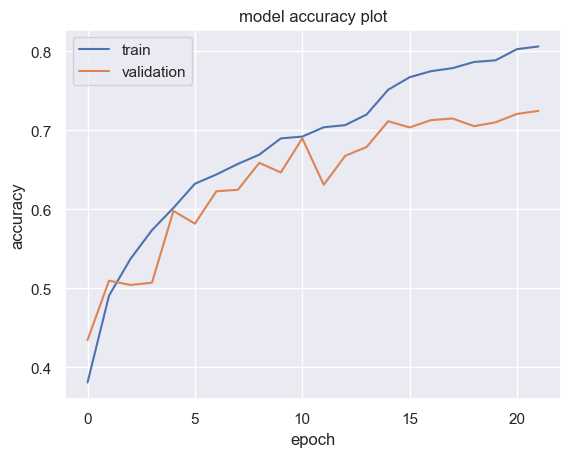

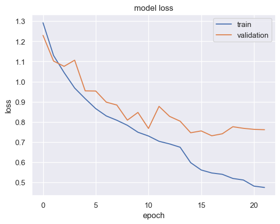

```python
plt.plot(history_cnn_1.history['accuracy'])
plt.plot(history_cnn_1.history['val_accuracy'])

plt.title('model accuracy plot')
plt.ylabel('accuracy')
plt.xlabel('epoch')
plt.legend(['train', 'validation'])

plt.show()

plt.plot(history_cnn_1.history['loss'])
plt.plot(history_cnn_1.history['val_loss'])

plt.title('model loss')
plt.ylabel('loss')
plt.xlabel('epoch')
plt.legend(['train', 'validation'])

plt.show()
```

```python
accuracy = cnn_1.evaluate(test_images, test_labels, verbose = 2)
```

```
4/4 - 0s - 20ms/step - accuracy: 0.7344 - loss: 0.6917
```

```python
#saving model name and accuracy
scoreboard_name.append('cnn_1')
scoreboard_acc.append(accuracy)

scoreboard.append(['cnn_1', accuracy[1]])
```

**Observations and Insights:**

- Our best grayscale CNN yet when evaluated on the test set: 73% accuracy.
- Our validation loss (0.76) starts to plateau at the 17th epoch, while it continues to improve with respect to our training data.
- The accuracy on our training data reached 80% and on our validation data 72% at the 22nd epoch.
- We should consider adding dropout layers in future iterations to reduce the overfitting we've been seeing across our past 3 models.
- This model is not giving a generalized performance even though it has performed better than our previous ones with respect to the test set.
- We will try more complex models down the line, and also see if we can optimize this one by changing the architecture to reduce overfitting, but for now lets use this model and the better base CNN model with rgb images to compare.

## **RGB**

Using and comparing our base CNN and our third CNN grayscale models to accept rgb images and find out whether rgb image makes an impact on performance.

### **Reinitializing our DataLoaders to change color mode to rgb**

```python
batch_size  = 32

datagen_train = ImageDataGenerator(horizontal_flip = True,
                                    brightness_range=(0.,2.),
                                    width_shift_range = 0.2,
                                    height_shift_range = 0.2,
                                    rescale=1./255,
                                    zoom_range = 0.2,
                                    shear_range=0.2,
                                    fill_mode = 'nearest')

train_set = datagen_train.flow_from_directory(DATADIR,
                                              target_size = (IMG_SIZE, IMG_SIZE),
                                              color_mode = 'rgb' ,
                                              batch_size = batch_size,
                                              class_mode = 'categorical',
                                              classes = ['happy', 'neutral', 'sad', 'surprise'],
                                              shuffle = True)


datagen_val = ImageDataGenerator(horizontal_flip = True,
                                    brightness_range=(0.,2.),
                                    width_shift_range = 0.2,
                                    height_shift_range = 0.2,
                                    rescale=1./255,
                                    zoom_range = 0.2,
                                    shear_range=0.2,
                                    fill_mode = 'nearest')

val_set = datagen_val.flow_from_directory(DATADIR_VAL,
                                              target_size = (IMG_SIZE, IMG_SIZE),
                                              color_mode = 'rgb' ,
                                              batch_size = batch_size,
                                              class_mode = 'categorical',
                                              classes = ['happy', 'neutral', 'sad', 'surprise'],
                                              shuffle = True)


datagen_test = ImageDataGenerator(horizontal_flip = True,
                                    brightness_range=(0.,2.),
                                    width_shift_range = 0.2,
                                    height_shift_range = 0.2,
                                    rescale=1./255,
                                    zoom_range = 0.2,
                                    shear_range=0.2,
                                    fill_mode = 'nearest')

test_set = datagen_test.flow_from_directory(DATADIR_TEST,
                                              target_size = (IMG_SIZE, IMG_SIZE),
                                              color_mode = 'rgb' ,
                                              batch_size = batch_size_testing,
                                              class_mode = 'categorical',
                                              classes = ['happy', 'neutral', 'sad', 'surprise'],
                                              shuffle = True)
```

```
Found 15109 images belonging to 4 classes.
Found 4977 images belonging to 4 classes.
Found 128 images belonging to 4 classes.
```

### **Base CNN Model (rgb)**

#### **Defining and Compiling the Model**

```python
from tensorflow.keras import backend
backend.clear_session()
```

```python
np.random.seed(25)
random.seed(25)
tf.random.set_seed(25)
```

```python
def cnn_model_base_rgb():

    model = Sequential()
    model.add(Input(shape = (IMG_SIZE, IMG_SIZE, 3))) #, input_shape = (IMG_SIZE, IMG_SIZE, 1)))

    model.add(Conv2D(filters = 64, kernel_size = (3,3), activation = 'relu', padding='same'))
    model.add(MaxPooling2D(pool_size=(2,2)))

    model.add(Conv2D(filters = 32, kernel_size = (3,3), activation = 'relu', padding='same'))
    model.add(MaxPooling2D(pool_size=(2,2)))

    model.add(Conv2D(filters = 32, kernel_size = (3,3), activation = 'relu', padding='same'))
    model.add(MaxPooling2D(pool_size=(2,2)))

    model.add(Flatten())

    model.add(Dense(256))
    model.add(LeakyReLU(0.1))

    model.add(Dense(4, activation = 'softmax'))

    opt = SGD(learning_rate = 0.01, momentum = 0.9)

    model.compile(loss = "categorical_crossentropy", optimizer = opt, metrics = ["accuracy"])

    return model
```

```python
cnn_base_rgb = cnn_model_base_rgb()
cnn_base_rgb.summary()
```

```
Model: "sequential"
```

```
┏━━━━━━━━━━━━━━━━━━━━━━━━━━━━━━━━━┳━━━━━━━━━━━━━━━━━━━━━━━━┳━━━━━━━━━━━━━━━┓
┃ Layer (type)                    ┃ Output Shape           ┃       Param # ┃
┡━━━━━━━━━━━━━━━━━━━━━━━━━━━━━━━━━╇━━━━━━━━━━━━━━━━━━━━━━━━╇━━━━━━━━━━━━━━━┩
│ conv2d (Conv2D)                 │ (None, 48, 48, 64)     │         1,792 │
├─────────────────────────────────┼────────────────────────┼───────────────┤
│ max_pooling2d (MaxPooling2D)    │ (None, 24, 24, 64)     │             0 │
├─────────────────────────────────┼────────────────────────┼───────────────┤
│ conv2d_1 (Conv2D)               │ (None, 24, 24, 32)     │        18,464 │
├─────────────────────────────────┼────────────────────────┼───────────────┤
│ max_pooling2d_1 (MaxPooling2D)  │ (None, 12, 12, 32)     │             0 │
├─────────────────────────────────┼────────────────────────┼───────────────┤
│ conv2d_2 (Conv2D)               │ (None, 12, 12, 32)     │         9,248 │
├─────────────────────────────────┼────────────────────────┼───────────────┤
│ max_pooling2d_2 (MaxPooling2D)  │ (None, 6, 6, 32)       │             0 │
├─────────────────────────────────┼────────────────────────┼───────────────┤
│ flatten (Flatten)               │ (None, 1152)           │             0 │
├─────────────────────────────────┼────────────────────────┼───────────────┤
│ dense (Dense)                   │ (None, 256)            │       295,168 │
├─────────────────────────────────┼────────────────────────┼───────────────┤
│ leaky_re_lu (LeakyReLU)         │ (None, 256)            │             0 │
├─────────────────────────────────┼────────────────────────┼───────────────┤
│ dense_1 (Dense)                 │ (None, 4)              │         1,028 │
└─────────────────────────────────┴────────────────────────┴───────────────┘
```

```
 Total params: 325,700 (1.24 MB)
```

```
 Trainable params: 325,700 (1.24 MB)
```

```
 Non-trainable params: 0 (0.00 B)
```

```python
early_stop = EarlyStopping(monitor='val_loss', mode = 'min', patience = 5, verbose = 1, restore_best_weights = True)
checkpoint = ModelCheckpoint('best_model_base_rgb.keras', monitor='val_loss', mode = 'min', verbose = 1, save_best_only = True)
reduce_lr = ReduceLROnPlateau(monitor = 'val_loss', factor = 0.2, patience = 3, verbose = 1, min_delta = 0.0001)

history_cnn_base_rgb = cnn_base_rgb.fit(train_set, validation_data = val_set, epochs = 200, verbose = 1, callbacks = [early_stop, checkpoint, reduce_lr])
```

```
  1/473 ━━━━━━━━━━━━━━━━━━━━ 5:43 728ms/step - accuracy: 0.1875 - loss: 1.3905
```

```
471/473 ━━━━━━━━━━━━━━━━━━━━ 0s 25ms/step - accuracy: 0.2654 - loss: 1.3826
Epoch 1: val_loss improved from inf to 1.35182, saving model to best_model_base_rgb.keras
473/473 ━━━━━━━━━━━━━━━━━━━━ 16s 32ms/step - accuracy: 0.2655 - loss: 1.3825 - val_accuracy: 0.3285 - val_loss: 1.3518 - learning_rate: 0.0100
473/473 ━━━━━━━━━━━━━━━━━━━━ 0s 25ms/step - accuracy: 0.3038 - loss: 1.3695
Epoch 2: val_loss improved from 1.35182 to 1.33309, saving model to best_model_base_rgb.keras
473/473 ━━━━━━━━━━━━━━━━━━━━ 15s 32ms/step - accuracy: 0.3038 - loss: 1.3695 - val_accuracy: 0.3197 - val_loss: 1.3331 - learning_rate: 0.0100
471/473 ━━━━━━━━━━━━━━━━━━━━ 0s 25ms/step - accuracy: 0.3239 - loss: 1.3451
Epoch 3: val_loss improved from 1.33309 to 1.32442, saving model to best_model_base_rgb.keras
473/473 ━━━━━━━━━━━━━━━━━━━━ 15s 32ms/step - accuracy: 0.3239 - loss: 1.3451 - val_accuracy: 0.3446 - val_loss: 1.3244 - learning_rate: 0.0100
467/473 ━━━━━━━━━━━━━━━━━━━━ 0s 25ms/step - accuracy: 0.3400 - loss: 1.3255
Epoch 4: val_loss improved from 1.32442 to 1.31064, saving model to best_model_base_rgb.keras
473/473 ━━━━━━━━━━━━━━━━━━━━ 15s 32ms/step - accuracy: 0.3401 - loss: 1.3254 - val_accuracy: 0.3591 - val_loss: 1.3106 - learning_rate: 0.0100
472/473 ━━━━━━━━━━━━━━━━━━━━ 0s 25ms/step - accuracy: 0.3632 - loss: 1.3076
Epoch 5: val_loss improved from 1.31064 to 1.29715, saving model to best_model_base_rgb.keras
473/473 ━━━━━━━━━━━━━━━━━━━━ 15s 32ms/step - accuracy: 0.3632 - loss: 1.3076 - val_accuracy: 0.3842 - val_loss: 1.2971 - learning_rate: 0.0100
467/473 ━━━━━━━━━━━━━━━━━━━━ 0s 25ms/step - accuracy: 0.3688 - loss: 1.2961
Epoch 6: val_loss did not improve from 1.29715
473/473 ━━━━━━━━━━━━━━━━━━━━ 15s 32ms/step - accuracy: 0.3689 - loss: 1.2960 - val_accuracy: 0.3221 - val_loss: 1.3764 - learning_rate: 0.0100
471/473 ━━━━━━━━━━━━━━━━━━━━ 0s 25ms/step - accuracy: 0.3886 - loss: 1.2756
Epoch 7: val_loss improved from 1.29715 to 1.28214, saving model to best_model_base_rgb.keras
473/473 ━━━━━━━━━━━━━━━━━━━━ 15s 32ms/step - accuracy: 0.3886 - loss: 1.2755 - val_accuracy: 0.3797 - val_loss: 1.2821 - learning_rate: 0.0100
467/473 ━━━━━━━━━━━━━━━━━━━━ 0s 25ms/step - accuracy: 0.4187 - loss: 1.2462
Epoch 8: val_loss did not improve from 1.28214
473/473 ━━━━━━━━━━━━━━━━━━━━ 15s 32ms/step - accuracy: 0.4186 - loss: 1.2463 - val_accuracy: 0.3729 - val_loss: 1.2969 - learning_rate: 0.0100
467/473 ━━━━━━━━━━━━━━━━━━━━ 0s 25ms/step - accuracy: 0.4252 - loss: 1.2339
Epoch 9: val_loss improved from 1.28214 to 1.19629, saving model to best_model_base_rgb.keras
473/473 ━━━━━━━━━━━━━━━━━━━━ 15s 32ms/step - accuracy: 0.4253 - loss: 1.2337 - val_accuracy: 0.4611 - val_loss: 1.1963 - learning_rate: 0.0100
467/473 ━━━━━━━━━━━━━━━━━━━━ 0s 25ms/step - accuracy: 0.4398 - loss: 1.2146
Epoch 10: val_loss improved from 1.19629 to 1.19490, saving model to best_model_base_rgb.keras
473/473 ━━━━━━━━━━━━━━━━━━━━ 15s 32ms/step - accuracy: 0.4399 - loss: 1.2145 - val_accuracy: 0.4573 - val_loss: 1.1949 - learning_rate: 0.0100
471/473 ━━━━━━━━━━━━━━━━━━━━ 0s 25ms/step - accuracy: 0.4567 - loss: 1.1880
Epoch 11: val_loss did not improve from 1.19490
473/473 ━━━━━━━━━━━━━━━━━━━━ 15s 32ms/step - accuracy: 0.4567 - loss: 1.1880 - val_accuracy: 0.4603 - val_loss: 1.2068 - learning_rate: 0.0100
466/473 ━━━━━━━━━━━━━━━━━━━━ 0s 25ms/step - accuracy: 0.4615 - loss: 1.1720
Epoch 12: val_loss improved from 1.19490 to 1.14086, saving model to best_model_base_rgb.keras
473/473 ━━━━━━━━━━━━━━━━━━━━ 15s 32ms/step - accuracy: 0.4617 - loss: 1.1719 - val_accuracy: 0.4886 - val_loss: 1.1409 - learning_rate: 0.0100
466/473 ━━━━━━━━━━━━━━━━━━━━ 0s 25ms/step - accuracy: 0.4734 - loss: 1.1485
Epoch 13: val_loss improved from 1.14086 to 1.12582, saving model to best_model_base_rgb.keras
473/473 ━━━━━━━━━━━━━━━━━━━━ 15s 32ms/step - accuracy: 0.4735 - loss: 1.1483 - val_accuracy: 0.5067 - val_loss: 1.1258 - learning_rate: 0.0100
466/473 ━━━━━━━━━━━━━━━━━━━━ 0s 25ms/step - accuracy: 0.4974 - loss: 1.1101
```

[output cut: 90 more lines]

```
Epoch 42: val_loss did not improve from 0.85935
473/473 ━━━━━━━━━━━━━━━━━━━━ 16s 34ms/step - accuracy: 0.6290 - loss: 0.8702 - val_accuracy: 0.6373 - val_loss: 0.8794 - learning_rate: 8.0000e-05
470/473 ━━━━━━━━━━━━━━━━━━━━ 0s 27ms/step - accuracy: 0.6263 - loss: 0.8746
Epoch 43: val_loss did not improve from 0.85935

Epoch 43: ReduceLROnPlateau reducing learning rate to 1.599999814061448e-05.
473/473 ━━━━━━━━━━━━━━━━━━━━ 16s 34ms/step - accuracy: 0.6264 - loss: 0.8746 - val_accuracy: 0.6407 - val_loss: 0.8742 - learning_rate: 8.0000e-05
466/473 ━━━━━━━━━━━━━━━━━━━━ 0s 26ms/step - accuracy: 0.6343 - loss: 0.8723
Epoch 44: val_loss did not improve from 0.85935
473/473 ━━━━━━━━━━━━━━━━━━━━ 16s 34ms/step - accuracy: 0.6342 - loss: 0.8723 - val_accuracy: 0.6343 - val_loss: 0.8684 - learning_rate: 1.6000e-05
471/473 ━━━━━━━━━━━━━━━━━━━━ 0s 25ms/step - accuracy: 0.6335 - loss: 0.8724
Epoch 45: val_loss did not improve from 0.85935
473/473 ━━━━━━━━━━━━━━━━━━━━ 15s 32ms/step - accuracy: 0.6335 - loss: 0.8724 - val_accuracy: 0.6365 - val_loss: 0.8674 - learning_rate: 1.6000e-05
Epoch 45: early stopping
Restoring model weights from the end of the best epoch: 40.
```

### **Model Evaluation**

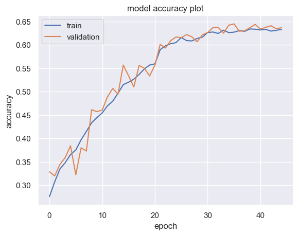

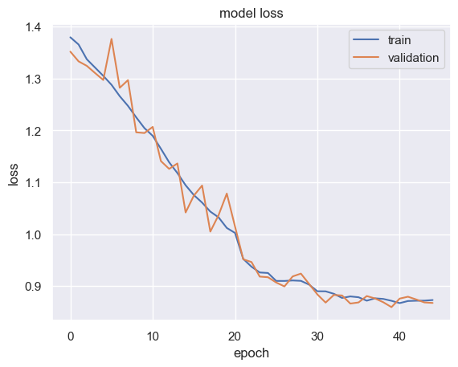

```python
plt.plot(history_cnn_base_rgb.history['accuracy'])
plt.plot(history_cnn_base_rgb.history['val_accuracy'])

plt.title('model accuracy plot')
plt.ylabel('accuracy')
plt.xlabel('epoch')
plt.legend(['train', 'validation'])

plt.show()

plt.plot(history_cnn_base_rgb.history['loss'])
plt.plot(history_cnn_base_rgb.history['val_loss'])

plt.title('model loss')
plt.ylabel('loss')
plt.xlabel('epoch')
plt.legend(['train', 'validation'])

plt.show()
```

```python
test_images, test_labels = next(test_set)
accuracy = cnn_base_rgb.evaluate(test_images, test_labels, verbose = 2)
```

```
4/4 - 0s - 6ms/step - accuracy: 0.6406 - loss: 0.8015
```

```python
#saving model name and accuracy
scoreboard_name.append('cnn_base_rgb')
scoreboard_acc.append(accuracy)

scoreboard.append(['cnn_base_rgb', accuracy[1]])
```

**Observations and Insights:**

- The many spikes in our validation data graphs could stem from the imbalance in the validation data that we saw earlier in preprocessing.
- This rgb version of our base model did not perform nearly as well.
- Our accuracy and loss for our training and validation sets plateaued at around 63% and 0.87 respectively.
- However, we can say that this model gives generalized performance because of how close the performance of training and validation are to one another. This is interesting since our grayscale version did not, and we did not change anything except for the colormode of our images.
- This model achieved an accuracy of 64% on our test set, recall that the grayscale version acheived an accuracy of 68%.
- For now, we can say that our grayscale models are better, but lets try one more.

### **Second CNN Model (rgb)**

#### **Defining and Compiling the Model**

```python
backend.clear_session()
```

```python
np.random.seed(25)
random.seed(25)
tf.random.set_seed(25)
```

```python
def cnn_model_rgb1():

    model = Sequential()
    model.add(Input(shape = (IMG_SIZE, IMG_SIZE, 3))) #input layer

    model.add(Conv2D(filters = 256, kernel_size = (3,3), activation = 'relu', padding='same')) # conv1
    model.add(BatchNormalization())
    model.add(LeakyReLU(0.1))
    model.add(MaxPooling2D(pool_size=(2,2)))

    model.add(Conv2D(filters = 128, kernel_size = (3,3), activation = 'relu', padding='same')) #conv 2
    model.add(BatchNormalization())
    model.add(LeakyReLU(0.1))
    model.add(MaxPooling2D(pool_size=(2,2)))


    model.add(Conv2D(filters = 64, kernel_size = (3,3), activation = 'relu', padding='same')) #conv 3
    model.add(BatchNormalization())
    model.add(LeakyReLU(0.1))
    model.add(MaxPooling2D(pool_size=(2,2)))

    model.add(Conv2D(filters = 32, kernel_size = (3,3), activation = 'relu', padding='same')) #conv 4
    model.add(BatchNormalization())
    model.add(LeakyReLU(0.1))
    model.add(MaxPooling2D(pool_size=(2,2)))

    model.add(Flatten())

    model.add(Dense(512, activation = 'relu'))
    model.add(Dense(128, activation = 'relu'))

    model.add(Dense(4, activation = 'softmax')) #output layer

    opt = SGD(learning_rate = 0.01, momentum = 0.9)

    model.compile(loss = "categorical_crossentropy", optimizer = opt, metrics = ["accuracy"])

    return model
```

```python
cnn1_rgb = cnn_model_rgb1()
cnn1_rgb.summary()
```

```
Model: "sequential"
```

```
┏━━━━━━━━━━━━━━━━━━━━━━━━━━━━━━━━━┳━━━━━━━━━━━━━━━━━━━━━━━━┳━━━━━━━━━━━━━━━┓
┃ Layer (type)                    ┃ Output Shape           ┃       Param # ┃
┡━━━━━━━━━━━━━━━━━━━━━━━━━━━━━━━━━╇━━━━━━━━━━━━━━━━━━━━━━━━╇━━━━━━━━━━━━━━━┩
│ conv2d (Conv2D)                 │ (None, 48, 48, 256)    │         7,168 │
├─────────────────────────────────┼────────────────────────┼───────────────┤
│ batch_normalization             │ (None, 48, 48, 256)    │         1,024 │
│ (BatchNormalization)            │                        │               │
├─────────────────────────────────┼────────────────────────┼───────────────┤
│ leaky_re_lu (LeakyReLU)         │ (None, 48, 48, 256)    │             0 │
├─────────────────────────────────┼────────────────────────┼───────────────┤
│ max_pooling2d (MaxPooling2D)    │ (None, 24, 24, 256)    │             0 │
├─────────────────────────────────┼────────────────────────┼───────────────┤
│ conv2d_1 (Conv2D)               │ (None, 24, 24, 128)    │       295,040 │
├─────────────────────────────────┼────────────────────────┼───────────────┤
│ batch_normalization_1           │ (None, 24, 24, 128)    │           512 │
│ (BatchNormalization)            │                        │               │
├─────────────────────────────────┼────────────────────────┼───────────────┤
│ leaky_re_lu_1 (LeakyReLU)       │ (None, 24, 24, 128)    │             0 │
├─────────────────────────────────┼────────────────────────┼───────────────┤
│ max_pooling2d_1 (MaxPooling2D)  │ (None, 12, 12, 128)    │             0 │
├─────────────────────────────────┼────────────────────────┼───────────────┤
│ conv2d_2 (Conv2D)               │ (None, 12, 12, 64)     │        73,792 │
├─────────────────────────────────┼────────────────────────┼───────────────┤
│ batch_normalization_2           │ (None, 12, 12, 64)     │           256 │
│ (BatchNormalization)            │                        │               │
├─────────────────────────────────┼────────────────────────┼───────────────┤
│ leaky_re_lu_2 (LeakyReLU)       │ (None, 12, 12, 64)     │             0 │
├─────────────────────────────────┼────────────────────────┼───────────────┤
│ max_pooling2d_2 (MaxPooling2D)  │ (None, 6, 6, 64)       │             0 │
├─────────────────────────────────┼────────────────────────┼───────────────┤
│ conv2d_3 (Conv2D)               │ (None, 6, 6, 32)       │        18,464 │
├─────────────────────────────────┼────────────────────────┼───────────────┤
│ batch_normalization_3           │ (None, 6, 6, 32)       │           128 │
│ (BatchNormalization)            │                        │               │
├─────────────────────────────────┼────────────────────────┼───────────────┤
│ leaky_re_lu_3 (LeakyReLU)       │ (None, 6, 6, 32)       │             0 │
├─────────────────────────────────┼────────────────────────┼───────────────┤
│ max_pooling2d_3 (MaxPooling2D)  │ (None, 3, 3, 32)       │             0 │
├─────────────────────────────────┼────────────────────────┼───────────────┤
│ flatten (Flatten)               │ (None, 288)            │             0 │
├─────────────────────────────────┼────────────────────────┼───────────────┤
│ dense (Dense)                   │ (None, 512)            │       147,968 │
├─────────────────────────────────┼────────────────────────┼───────────────┤
│ dense_1 (Dense)                 │ (None, 128)            │        65,664 │
├─────────────────────────────────┼────────────────────────┼───────────────┤
│ dense_2 (Dense)                 │ (None, 4)              │           516 │
└─────────────────────────────────┴────────────────────────┴───────────────┘
```

```
 Total params: 610,532 (2.33 MB)
```

```
 Trainable params: 609,572 (2.33 MB)
```

```
 Non-trainable params: 960 (3.75 KB)
```

```python
early_stop = EarlyStopping(monitor='val_loss', mode = 'min', patience = 5, verbose = 1, restore_best_weights = True)
checkpoint = ModelCheckpoint('best_model_rgb1.keras', monitor='val_loss', mode = 'min', verbose = 1, save_best_only = True)
reduce_lr = ReduceLROnPlateau(monitor = 'val_loss', factor = 0.2, patience = 3, verbose = 1, min_delta = 0.0001)

history_cnn1_rgb = cnn1_rgb.fit(train_set, validation_data = val_set, epochs = 200, verbose = 1, callbacks = [early_stop, checkpoint, reduce_lr])
```

```
473/473 ━━━━━━━━━━━━━━━━━━━━ 0s 109ms/step - accuracy: 0.2789 - loss: 1.4188
Epoch 1: val_loss improved from inf to 1.33872, saving model to best_model_rgb1.keras
473/473 ━━━━━━━━━━━━━━━━━━━━ 58s 120ms/step - accuracy: 0.2790 - loss: 1.4187 - val_accuracy: 0.3289 - val_loss: 1.3387 - learning_rate: 0.0100
473/473 ━━━━━━━━━━━━━━━━━━━━ 0s 109ms/step - accuracy: 0.3350 - loss: 1.3213
Epoch 2: val_loss improved from 1.33872 to 1.33326, saving model to best_model_rgb1.keras
473/473 ━━━━━━━━━━━━━━━━━━━━ 57s 119ms/step - accuracy: 0.3350 - loss: 1.3213 - val_accuracy: 0.3595 - val_loss: 1.3333 - learning_rate: 0.0100
473/473 ━━━━━━━━━━━━━━━━━━━━ 0s 109ms/step - accuracy: 0.3640 - loss: 1.2938
Epoch 3: val_loss improved from 1.33326 to 1.28638, saving model to best_model_rgb1.keras
473/473 ━━━━━━━━━━━━━━━━━━━━ 57s 119ms/step - accuracy: 0.3640 - loss: 1.2938 - val_accuracy: 0.3197 - val_loss: 1.2864 - learning_rate: 0.0100
473/473 ━━━━━━━━━━━━━━━━━━━━ 0s 109ms/step - accuracy: 0.3771 - loss: 1.2723
Epoch 4: val_loss did not improve from 1.28638
473/473 ━━━━━━━━━━━━━━━━━━━━ 57s 119ms/step - accuracy: 0.3771 - loss: 1.2722 - val_accuracy: 0.3410 - val_loss: 1.2916 - learning_rate: 0.0100
473/473 ━━━━━━━━━━━━━━━━━━━━ 0s 109ms/step - accuracy: 0.4124 - loss: 1.2248
Epoch 5: val_loss improved from 1.28638 to 1.23996, saving model to best_model_rgb1.keras
473/473 ━━━━━━━━━━━━━━━━━━━━ 57s 120ms/step - accuracy: 0.4124 - loss: 1.2248 - val_accuracy: 0.3530 - val_loss: 1.2400 - learning_rate: 0.0100
473/473 ━━━━━━━━━━━━━━━━━━━━ 0s 109ms/step - accuracy: 0.4391 - loss: 1.1849
Epoch 6: val_loss did not improve from 1.23996
473/473 ━━━━━━━━━━━━━━━━━━━━ 57s 120ms/step - accuracy: 0.4392 - loss: 1.1849 - val_accuracy: 0.3896 - val_loss: 1.2482 - learning_rate: 0.0100
473/473 ━━━━━━━━━━━━━━━━━━━━ 0s 109ms/step - accuracy: 0.4685 - loss: 1.1584
Epoch 7: val_loss improved from 1.23996 to 1.14380, saving model to best_model_rgb1.keras
473/473 ━━━━━━━━━━━━━━━━━━━━ 57s 120ms/step - accuracy: 0.4686 - loss: 1.1584 - val_accuracy: 0.4820 - val_loss: 1.1438 - learning_rate: 0.0100
473/473 ━━━━━━━━━━━━━━━━━━━━ 0s 109ms/step - accuracy: 0.4859 - loss: 1.1165
Epoch 8: val_loss did not improve from 1.14380
473/473 ━━━━━━━━━━━━━━━━━━━━ 57s 119ms/step - accuracy: 0.4859 - loss: 1.1164 - val_accuracy: 0.4354 - val_loss: 1.2244 - learning_rate: 0.0100
473/473 ━━━━━━━━━━━━━━━━━━━━ 0s 109ms/step - accuracy: 0.5190 - loss: 1.0804
Epoch 9: val_loss improved from 1.14380 to 1.02214, saving model to best_model_rgb1.keras
473/473 ━━━━━━━━━━━━━━━━━━━━ 57s 120ms/step - accuracy: 0.5190 - loss: 1.0803 - val_accuracy: 0.5451 - val_loss: 1.0221 - learning_rate: 0.0100
473/473 ━━━━━━━━━━━━━━━━━━━━ 0s 109ms/step - accuracy: 0.5329 - loss: 1.0450
Epoch 10: val_loss did not improve from 1.02214
473/473 ━━━━━━━━━━━━━━━━━━━━ 57s 119ms/step - accuracy: 0.5329 - loss: 1.0449 - val_accuracy: 0.4736 - val_loss: 1.1362 - learning_rate: 0.0100
473/473 ━━━━━━━━━━━━━━━━━━━━ 0s 109ms/step - accuracy: 0.5542 - loss: 1.0126
Epoch 11: val_loss did not improve from 1.02214
473/473 ━━━━━━━━━━━━━━━━━━━━ 57s 119ms/step - accuracy: 0.5542 - loss: 1.0126 - val_accuracy: 0.5324 - val_loss: 1.0399 - learning_rate: 0.0100
473/473 ━━━━━━━━━━━━━━━━━━━━ 0s 109ms/step - accuracy: 0.5633 - loss: 1.0031
Epoch 12: val_loss improved from 1.02214 to 0.97071, saving model to best_model_rgb1.keras
473/473 ━━━━━━━━━━━━━━━━━━━━ 57s 119ms/step - accuracy: 0.5633 - loss: 1.0031 - val_accuracy: 0.5847 - val_loss: 0.9707 - learning_rate: 0.0100
473/473 ━━━━━━━━━━━━━━━━━━━━ 0s 111ms/step - accuracy: 0.5933 - loss: 0.9453
Epoch 13: val_loss did not improve from 0.97071
473/473 ━━━━━━━━━━━━━━━━━━━━ 58s 121ms/step - accuracy: 0.5933 - loss: 0.9453 - val_accuracy: 0.5809 - val_loss: 0.9718 - learning_rate: 0.0100
473/473 ━━━━━━━━━━━━━━━━━━━━ 0s 110ms/step - accuracy: 0.5909 - loss: 0.9498
```

[output cut: 103 more lines]

```
Epoch 47: val_loss did not improve from 0.68571
473/473 ━━━━━━━━━━━━━━━━━━━━ 57s 120ms/step - accuracy: 0.7186 - loss: 0.6812 - val_accuracy: 0.7141 - val_loss: 0.7094 - learning_rate: 4.0000e-04
473/473 ━━━━━━━━━━━━━━━━━━━━ 0s 109ms/step - accuracy: 0.7232 - loss: 0.6788
Epoch 48: val_loss did not improve from 0.68571

Epoch 48: ReduceLROnPlateau reducing learning rate to 7.999999215826393e-05.
473/473 ━━━━━━━━━━━━━━━━━━━━ 57s 119ms/step - accuracy: 0.7232 - loss: 0.6788 - val_accuracy: 0.7185 - val_loss: 0.6909 - learning_rate: 4.0000e-04
473/473 ━━━━━━━━━━━━━━━━━━━━ 0s 110ms/step - accuracy: 0.7274 - loss: 0.6716
Epoch 49: val_loss did not improve from 0.68571
473/473 ━━━━━━━━━━━━━━━━━━━━ 57s 120ms/step - accuracy: 0.7274 - loss: 0.6716 - val_accuracy: 0.7195 - val_loss: 0.7064 - learning_rate: 8.0000e-05
473/473 ━━━━━━━━━━━━━━━━━━━━ 0s 109ms/step - accuracy: 0.7065 - loss: 0.6957
Epoch 50: val_loss did not improve from 0.68571
473/473 ━━━━━━━━━━━━━━━━━━━━ 57s 120ms/step - accuracy: 0.7065 - loss: 0.6957 - val_accuracy: 0.7195 - val_loss: 0.7052 - learning_rate: 8.0000e-05
Epoch 50: early stopping
Restoring model weights from the end of the best epoch: 45.
```

### **Model Evaluation**

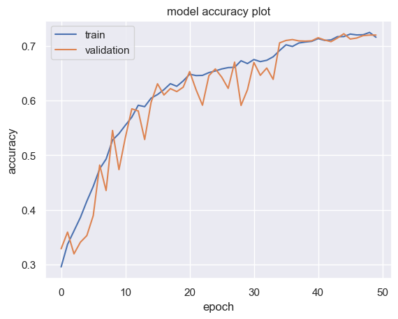

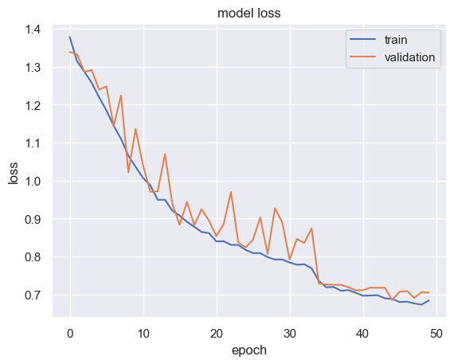

```python
plt.plot(history_cnn1_rgb.history['accuracy'])
plt.plot(history_cnn1_rgb.history['val_accuracy'])

plt.title('model accuracy plot')
plt.ylabel('accuracy')
plt.xlabel('epoch')
plt.legend(['train', 'validation'])

plt.show()

plt.plot(history_cnn1_rgb.history['loss'])
plt.plot(history_cnn1_rgb.history['val_loss'])

plt.title('model loss')
plt.ylabel('loss')
plt.xlabel('epoch')
plt.legend(['train', 'validation'])

plt.show()
```

```python
accuracy = cnn1_rgb.evaluate(test_images, test_labels, verbose = 2)
```

```
4/4 - 0s - 23ms/step - accuracy: 0.7656 - loss: 0.5794
```

```python
#saving model name and accuracy
scoreboard_name.append('cnn1_rgb')
scoreboard_acc.append(accuracy)

scoreboard.append(['cnn1_rgb', accuracy[1]])
```

**Observations and Insights:**

- We've achieved the highest accuracy on our test set so far: 76%
- The accuracy and loss for our training and validation data have plateaued at around 71% and 0.68 respectively.
- These numbers are lower than our comparative grayscale model but this model has performed better on the test set. A reason could be that this test set is not identical since we've generated a new test set when we changed the colormode in our Data Loader.
- We can also still see the imbalance of our validation data reflected above by the spikes in the graph.
- However, this model gives a generalized performance as it seems that the validation data "corrects" itself to match more closely with our training data.
- At this point, it is hard to say if this model is better than our grayscale version even though it performed better on the test set because of the points above.
- At this point, I'd suggest to stick to grayscale and finetune the hyperparameters. The rgb models take a much longer time to train, and has not made it clear that it gives a big performance boost compared to its grayscale counterparts.

## **Transfer Learning Architectures**

**NOTE**

We don't need to create new Data Loaders for our transfer learning architectures since our current ones already have the color mode RGB.

## **VGG16 Model**

### **Importing the VGG16 Architecture**

```python
backend.clear_session()

np.random.seed(25)
random.seed(25)
tf.random.set_seed(25)
```

```python
from tensorflow.keras.applications.vgg16 import VGG16
from tensorflow.keras import Model

vgg_model = VGG16(include_top = False, weights = 'imagenet', input_shape = (48, 48, 3))
vgg_model.summary()
```

```
Model: "vgg16"
```

```
┏━━━━━━━━━━━━━━━━━━━━━━━━━━━━━━━━━┳━━━━━━━━━━━━━━━━━━━━━━━━┳━━━━━━━━━━━━━━━┓
┃ Layer (type)                    ┃ Output Shape           ┃       Param # ┃
┡━━━━━━━━━━━━━━━━━━━━━━━━━━━━━━━━━╇━━━━━━━━━━━━━━━━━━━━━━━━╇━━━━━━━━━━━━━━━┩
│ input_layer (InputLayer)        │ (None, 48, 48, 3)      │             0 │
├─────────────────────────────────┼────────────────────────┼───────────────┤
│ block1_conv1 (Conv2D)           │ (None, 48, 48, 64)     │         1,792 │
├─────────────────────────────────┼────────────────────────┼───────────────┤
│ block1_conv2 (Conv2D)           │ (None, 48, 48, 64)     │        36,928 │
├─────────────────────────────────┼────────────────────────┼───────────────┤
│ block1_pool (MaxPooling2D)      │ (None, 24, 24, 64)     │             0 │
├─────────────────────────────────┼────────────────────────┼───────────────┤
│ block2_conv1 (Conv2D)           │ (None, 24, 24, 128)    │        73,856 │
├─────────────────────────────────┼────────────────────────┼───────────────┤
│ block2_conv2 (Conv2D)           │ (None, 24, 24, 128)    │       147,584 │
├─────────────────────────────────┼────────────────────────┼───────────────┤
│ block2_pool (MaxPooling2D)      │ (None, 12, 12, 128)    │             0 │
├─────────────────────────────────┼────────────────────────┼───────────────┤
│ block3_conv1 (Conv2D)           │ (None, 12, 12, 256)    │       295,168 │
├─────────────────────────────────┼────────────────────────┼───────────────┤
│ block3_conv2 (Conv2D)           │ (None, 12, 12, 256)    │       590,080 │
├─────────────────────────────────┼────────────────────────┼───────────────┤
│ block3_conv3 (Conv2D)           │ (None, 12, 12, 256)    │       590,080 │
├─────────────────────────────────┼────────────────────────┼───────────────┤
│ block3_pool (MaxPooling2D)      │ (None, 6, 6, 256)      │             0 │
├─────────────────────────────────┼────────────────────────┼───────────────┤
│ block4_conv1 (Conv2D)           │ (None, 6, 6, 512)      │     1,180,160 │
├─────────────────────────────────┼────────────────────────┼───────────────┤
│ block4_conv2 (Conv2D)           │ (None, 6, 6, 512)      │     2,359,808 │
├─────────────────────────────────┼────────────────────────┼───────────────┤
│ block4_conv3 (Conv2D)           │ (None, 6, 6, 512)      │     2,359,808 │
├─────────────────────────────────┼────────────────────────┼───────────────┤
│ block4_pool (MaxPooling2D)      │ (None, 3, 3, 512)      │             0 │
├─────────────────────────────────┼────────────────────────┼───────────────┤
│ block5_conv1 (Conv2D)           │ (None, 3, 3, 512)      │     2,359,808 │
├─────────────────────────────────┼────────────────────────┼───────────────┤
│ block5_conv2 (Conv2D)           │ (None, 3, 3, 512)      │     2,359,808 │
├─────────────────────────────────┼────────────────────────┼───────────────┤
│ block5_conv3 (Conv2D)           │ (None, 3, 3, 512)      │     2,359,808 │
├─────────────────────────────────┼────────────────────────┼───────────────┤
│ block5_pool (MaxPooling2D)      │ (None, 1, 1, 512)      │             0 │
└─────────────────────────────────┴────────────────────────┴───────────────┘
```

```
 Total params: 14,714,688 (56.13 MB)
```

```
 Trainable params: 14,714,688 (56.13 MB)
```

```
 Non-trainable params: 0 (0.00 B)
```

### **Model Building**

- Import VGG16 upto the layer of your choice and add Fully Connected layers on top of it.

```python
transfer_layer = vgg_model.get_layer('block5_pool')
vgg_model.trainable = False
```

```python
x = Flatten()(transfer_layer.output)

x = Dense(256, activation = 'relu')(x)
x = Dense(128, activation = 'relu')(x)

x = Dropout(0.3)(x)

x = Dense(64, activation = 'relu')(x)

x = BatchNormalization()(x)

pred = Dense(4, activation = 'softmax')(x)

vgg_model_1 = Model(vgg_model.input, pred)
```

### **Compiling and Training the VGG16 Model**

```python
opt = SGD(learning_rate = 0.01, momentum = 0.9)

vgg_model_1.compile(loss = "categorical_crossentropy", optimizer = opt, metrics = ["accuracy"])
```

```python
early_stop = EarlyStopping(monitor='val_loss', mode = 'min', patience = 5, verbose = 1, restore_best_weights = True)
checkpoint = ModelCheckpoint('best_vgg_model.keras', monitor='val_loss', mode = 'min', verbose = 1, save_best_only = True)
reduce_lr = ReduceLROnPlateau(monitor = 'val_loss', factor = 0.2, patience = 3, verbose = 1, min_delta = 0.0001)

history_vgg = vgg_model_1.fit(train_set, validation_data = val_set, epochs = 200, verbose = 1, callbacks = [early_stop, checkpoint, reduce_lr])
```

```
473/473 ━━━━━━━━━━━━━━━━━━━━ 0s 53ms/step - accuracy: 0.2678 - loss: 1.4713
Epoch 1: val_loss improved from inf to 1.34269, saving model to best_vgg_model.keras
473/473 ━━━━━━━━━━━━━━━━━━━━ 34s 70ms/step - accuracy: 0.2679 - loss: 1.4712 - val_accuracy: 0.2970 - val_loss: 1.3427 - learning_rate: 0.0100
473/473 ━━━━━━━━━━━━━━━━━━━━ 0s 53ms/step - accuracy: 0.3340 - loss: 1.3345
Epoch 2: val_loss improved from 1.34269 to 1.30421, saving model to best_vgg_model.keras
473/473 ━━━━━━━━━━━━━━━━━━━━ 33s 70ms/step - accuracy: 0.3340 - loss: 1.3345 - val_accuracy: 0.3229 - val_loss: 1.3042 - learning_rate: 0.0100
473/473 ━━━━━━━━━━━━━━━━━━━━ 0s 53ms/step - accuracy: 0.3689 - loss: 1.3102
Epoch 3: val_loss improved from 1.30421 to 1.25637, saving model to best_vgg_model.keras
473/473 ━━━━━━━━━━━━━━━━━━━━ 33s 70ms/step - accuracy: 0.3689 - loss: 1.3102 - val_accuracy: 0.3982 - val_loss: 1.2564 - learning_rate: 0.0100
473/473 ━━━━━━━━━━━━━━━━━━━━ 0s 53ms/step - accuracy: 0.3768 - loss: 1.2979
Epoch 4: val_loss improved from 1.25637 to 1.24006, saving model to best_vgg_model.keras
473/473 ━━━━━━━━━━━━━━━━━━━━ 33s 70ms/step - accuracy: 0.3768 - loss: 1.2979 - val_accuracy: 0.4342 - val_loss: 1.2401 - learning_rate: 0.0100
473/473 ━━━━━━━━━━━━━━━━━━━━ 0s 53ms/step - accuracy: 0.3916 - loss: 1.2855
Epoch 5: val_loss did not improve from 1.24006
473/473 ━━━━━━━━━━━━━━━━━━━━ 33s 69ms/step - accuracy: 0.3916 - loss: 1.2855 - val_accuracy: 0.4298 - val_loss: 1.2418 - learning_rate: 0.0100
473/473 ━━━━━━━━━━━━━━━━━━━━ 0s 53ms/step - accuracy: 0.3983 - loss: 1.2704
Epoch 6: val_loss did not improve from 1.24006
473/473 ━━━━━━━━━━━━━━━━━━━━ 33s 70ms/step - accuracy: 0.3983 - loss: 1.2704 - val_accuracy: 0.3645 - val_loss: 1.3192 - learning_rate: 0.0100
473/473 ━━━━━━━━━━━━━━━━━━━━ 0s 55ms/step - accuracy: 0.3988 - loss: 1.2743
Epoch 7: val_loss did not improve from 1.24006

Epoch 7: ReduceLROnPlateau reducing learning rate to 0.0019999999552965165.
473/473 ━━━━━━━━━━━━━━━━━━━━ 34s 71ms/step - accuracy: 0.3988 - loss: 1.2743 - val_accuracy: 0.3540 - val_loss: 1.2972 - learning_rate: 0.0100
473/473 ━━━━━━━━━━━━━━━━━━━━ 0s 54ms/step - accuracy: 0.4122 - loss: 1.2597
Epoch 8: val_loss improved from 1.24006 to 1.23369, saving model to best_vgg_model.keras
473/473 ━━━━━━━━━━━━━━━━━━━━ 34s 71ms/step - accuracy: 0.4122 - loss: 1.2597 - val_accuracy: 0.4240 - val_loss: 1.2337 - learning_rate: 0.0020
473/473 ━━━━━━━━━━━━━━━━━━━━ 0s 54ms/step - accuracy: 0.4190 - loss: 1.2438
Epoch 9: val_loss improved from 1.23369 to 1.22275, saving model to best_vgg_model.keras
473/473 ━━━━━━━━━━━━━━━━━━━━ 34s 71ms/step - accuracy: 0.4190 - loss: 1.2438 - val_accuracy: 0.4352 - val_loss: 1.2227 - learning_rate: 0.0020
472/473 ━━━━━━━━━━━━━━━━━━━━ 0s 54ms/step - accuracy: 0.4217 - loss: 1.2490
Epoch 10: val_loss improved from 1.22275 to 1.21760, saving model to best_vgg_model.keras
473/473 ━━━━━━━━━━━━━━━━━━━━ 34s 71ms/step - accuracy: 0.4217 - loss: 1.2490 - val_accuracy: 0.4412 - val_loss: 1.2176 - learning_rate: 0.0020
473/473 ━━━━━━━━━━━━━━━━━━━━ 0s 54ms/step - accuracy: 0.4242 - loss: 1.2431
Epoch 11: val_loss did not improve from 1.21760
473/473 ━━━━━━━━━━━━━━━━━━━━ 34s 71ms/step - accuracy: 0.4242 - loss: 1.2431 - val_accuracy: 0.4356 - val_loss: 1.2245 - learning_rate: 0.0020
473/473 ━━━━━━━━━━━━━━━━━━━━ 0s 54ms/step - accuracy: 0.4224 - loss: 1.2467
Epoch 12: val_loss did not improve from 1.21760
473/473 ━━━━━━━━━━━━━━━━━━━━ 33s 70ms/step - accuracy: 0.4224 - loss: 1.2467 - val_accuracy: 0.4384 - val_loss: 1.2282 - learning_rate: 0.0020
473/473 ━━━━━━━━━━━━━━━━━━━━ 0s 54ms/step - accuracy: 0.4351 - loss: 1.2244
Epoch 13: val_loss improved from 1.21760 to 1.20613, saving model to best_vgg_model.keras
473/473 ━━━━━━━━━━━━━━━━━━━━ 34s 71ms/step - accuracy: 0.4351 - loss: 1.2244 - val_accuracy: 0.4473 - val_loss: 1.2061 - learning_rate: 0.0020
472/473 ━━━━━━━━━━━━━━━━━━━━ 0s 54ms/step - accuracy: 0.4222 - loss: 1.2386
Epoch 14: val_loss did not improve from 1.20613
473/473 ━━━━━━━━━━━━━━━━━━━━ 33s 70ms/step - accuracy: 0.4222 - loss: 1.2386 - val_accuracy: 0.4268 - val_loss: 1.2204 - learning_rate: 0.0020
473/473 ━━━━━━━━━━━━━━━━━━━━ 0s 54ms/step - accuracy: 0.4306 - loss: 1.2265
Epoch 15: val_loss did not improve from 1.20613
473/473 ━━━━━━━━━━━━━━━━━━━━ 33s 70ms/step - accuracy: 0.4306 - loss: 1.2265 - val_accuracy: 0.4282 - val_loss: 1.2336 - learning_rate: 0.0020
472/473 ━━━━━━━━━━━━━━━━━━━━ 0s 54ms/step - accuracy: 0.4288 - loss: 1.2355
Epoch 16: val_loss did not improve from 1.20613

Epoch 16: ReduceLROnPlateau reducing learning rate to 0.0003999999724328518.
473/473 ━━━━━━━━━━━━━━━━━━━━ 34s 71ms/step - accuracy: 0.4288 - loss: 1.2355 - val_accuracy: 0.4075 - val_loss: 1.2488 - learning_rate: 0.0020
472/473 ━━━━━━━━━━━━━━━━━━━━ 0s 54ms/step - accuracy: 0.4381 - loss: 1.2222
Epoch 17: val_loss did not improve from 1.20613
473/473 ━━━━━━━━━━━━━━━━━━━━ 34s 71ms/step - accuracy: 0.4381 - loss: 1.2222 - val_accuracy: 0.4358 - val_loss: 1.2249 - learning_rate: 4.0000e-04
473/473 ━━━━━━━━━━━━━━━━━━━━ 0s 54ms/step - accuracy: 0.4331 - loss: 1.2235
Epoch 18: val_loss did not improve from 1.20613
473/473 ━━━━━━━━━━━━━━━━━━━━ 34s 71ms/step - accuracy: 0.4331 - loss: 1.2235 - val_accuracy: 0.4410 - val_loss: 1.2199 - learning_rate: 4.0000e-04
Epoch 18: early stopping
Restoring model weights from the end of the best epoch: 13.
```

### **Model Evaluation**

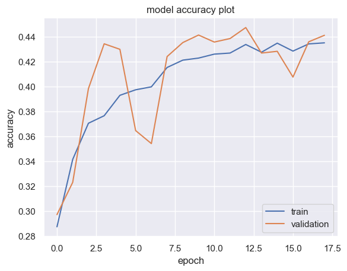

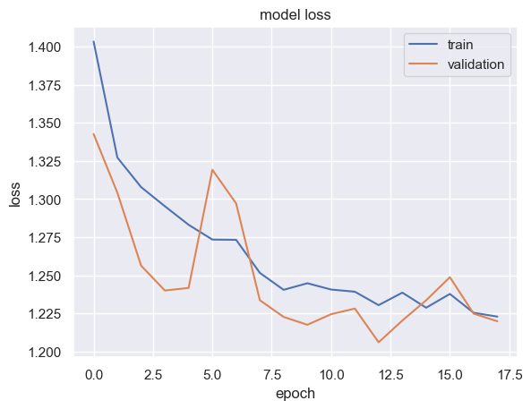

```python
plt.plot(history_vgg.history['accuracy'])
plt.plot(history_vgg.history['val_accuracy'])

plt.title('model accuracy plot')
plt.ylabel('accuracy')
plt.xlabel('epoch')
plt.legend(['train', 'validation'])

plt.show()

plt.plot(history_vgg.history['loss'])
plt.plot(history_vgg.history['val_loss'])

plt.title('model loss')
plt.ylabel('loss')
plt.xlabel('epoch')
plt.legend(['train', 'validation'])

plt.show()
```

```python
accuracy = vgg_model_1.evaluate(test_images, test_labels, verbose = 2)
```

```
4/4 - 0s - 53ms/step - accuracy: 0.4375 - loss: 1.2242
```

```python
#saving model name and accuracy
scoreboard_name.append('vgg_1')
scoreboard_acc.append(accuracy)

scoreboard.append(['vgg_1', accuracy[1]])
```

**Observations and Insights:**

- The accuracy of the training data continually improves up until the 12th epoch where it starts to oscillate.
- Overall the training performance starts well and starts to plateau rather quickly.
- The accuracy of the validation data starts oscillating to a much bigger degree as of the 3rd epoch.
- Let's try another transfer learning architecture.

```python
backend.clear_session()

np.random.seed(25)
random.seed(25)
tf.random.set_seed(25)
```

```python
import tensorflow.keras.applications as ap

Resnet = ap.ResNet101(include_top = False, weights = "imagenet", input_shape=(48,48,3))
Resnet.summary()
```

```
Model: "resnet101"
```

```
┏━━━━━━━━━━━━━━━━━━━━━┳━━━━━━━━━━━━━━━━━━━┳━━━━━━━━━━━━┳━━━━━━━━━━━━━━━━━━━┓
┃ Layer (type)        ┃ Output Shape      ┃    Param # ┃ Connected to      ┃
┡━━━━━━━━━━━━━━━━━━━━━╇━━━━━━━━━━━━━━━━━━━╇━━━━━━━━━━━━╇━━━━━━━━━━━━━━━━━━━┩
│ input_layer         │ (None, 48, 48, 3) │          0 │ -                 │
│ (InputLayer)        │                   │            │                   │
├─────────────────────┼───────────────────┼────────────┼───────────────────┤
│ conv1_pad           │ (None, 54, 54, 3) │          0 │ input_layer[0][0] │
│ (ZeroPadding2D)     │                   │            │                   │
├─────────────────────┼───────────────────┼────────────┼───────────────────┤
│ conv1_conv (Conv2D) │ (None, 24, 24,    │      9,472 │ conv1_pad[0][0]   │
│                     │ 64)               │            │                   │
├─────────────────────┼───────────────────┼────────────┼───────────────────┤
│ conv1_bn            │ (None, 24, 24,    │        256 │ conv1_conv[0][0]  │
│ (BatchNormalizatio… │ 64)               │            │                   │
├─────────────────────┼───────────────────┼────────────┼───────────────────┤
│ conv1_relu          │ (None, 24, 24,    │          0 │ conv1_bn[0][0]    │
│ (Activation)        │ 64)               │            │                   │
├─────────────────────┼───────────────────┼────────────┼───────────────────┤
│ pool1_pad           │ (None, 26, 26,    │          0 │ conv1_relu[0][0]  │
│ (ZeroPadding2D)     │ 64)               │            │                   │
├─────────────────────┼───────────────────┼────────────┼───────────────────┤
│ pool1_pool          │ (None, 12, 12,    │          0 │ pool1_pad[0][0]   │
│ (MaxPooling2D)      │ 64)               │            │                   │
├─────────────────────┼───────────────────┼────────────┼───────────────────┤
│ conv2_block1_1_conv │ (None, 12, 12,    │      4,160 │ pool1_pool[0][0]  │
│ (Conv2D)            │ 64)               │            │                   │
├─────────────────────┼───────────────────┼────────────┼───────────────────┤
│ conv2_block1_1_bn   │ (None, 12, 12,    │        256 │ conv2_block1_1_c… │
│ (BatchNormalizatio… │ 64)               │            │                   │
├─────────────────────┼───────────────────┼────────────┼───────────────────┤
│ conv2_block1_1_relu │ (None, 12, 12,    │          0 │ conv2_block1_1_b… │
│ (Activation)        │ 64)               │            │                   │
├─────────────────────┼───────────────────┼────────────┼───────────────────┤
│ conv2_block1_2_conv │ (None, 12, 12,    │     36,928 │ conv2_block1_1_r… │
│ (Conv2D)            │ 64)               │            │                   │
├─────────────────────┼───────────────────┼────────────┼───────────────────┤
│ conv2_block1_2_bn   │ (None, 12, 12,    │        256 │ conv2_block1_2_c… │
│ (BatchNormalizatio… │ 64)               │            │                   │
├─────────────────────┼───────────────────┼────────────┼───────────────────┤
│ conv2_block1_2_relu │ (None, 12, 12,    │          0 │ conv2_block1_2_b… │
```

[output cut: 983 more lines]

```
│ conv5_block3_2_relu │ (None, 2, 2, 512) │          0 │ conv5_block3_2_b… │
│ (Activation)        │                   │            │                   │
├─────────────────────┼───────────────────┼────────────┼───────────────────┤
│ conv5_block3_3_conv │ (None, 2, 2,      │  1,050,624 │ conv5_block3_2_r… │
│ (Conv2D)            │ 2048)             │            │                   │
├─────────────────────┼───────────────────┼────────────┼───────────────────┤
│ conv5_block3_3_bn   │ (None, 2, 2,      │      8,192 │ conv5_block3_3_c… │
│ (BatchNormalizatio… │ 2048)             │            │                   │
├─────────────────────┼───────────────────┼────────────┼───────────────────┤
│ conv5_block3_add    │ (None, 2, 2,      │          0 │ conv5_block2_out… │
│ (Add)               │ 2048)             │            │ conv5_block3_3_b… │
├─────────────────────┼───────────────────┼────────────┼───────────────────┤
│ conv5_block3_out    │ (None, 2, 2,      │          0 │ conv5_block3_add… │
│ (Activation)        │ 2048)             │            │                   │
└─────────────────────┴───────────────────┴────────────┴───────────────────┘
```

```
 Total params: 42,658,176 (162.73 MB)
```

```
 Trainable params: 42,552,832 (162.33 MB)
```

```
 Non-trainable params: 105,344 (411.50 KB)
```